# Análise de Churn

## Índice

1. Introdução
2. Data Wrangling
3. Análise Exploratória de Dados
4. Análise de churn e retenção de clientes

## 1. Introdução

VAI Pet atua no mercado de animais de estimação há mais de 10 anos com unidades físicas distribuídas no Nordeste do Brasil e, mais recentemente, com vendas online para todo o país. Além da venda de produtos, também possui em suas lojas físicas a clínica veterinária e serviços estéticos.

Desde o início do ano passado (2020), a VAI Pet iniciou um plano para evoluir a transformação digital da empresa e estruturação dos dados dos clientes para melhorar sua experiência. Com as análises realizadas, decidiram lançar um programa de fidelidade que permite identificar as compras dos clientes nas lojas físicas, onde possuem maior volume de vendas.

O CEO é analítico e orientado a resultados, participa ativamente das transformações da empresa, engaja e orienta o time nos planejamentos estratégicos. Como o time de dados da VAI Pet está focado em outras iniciativas da empresa, o CEO nos enviou a seguinte dúvida, pedindo a nossa ajuda para respondê-la.

- **Análise de churn e retenção de clientes:**  
  Uma das prioridades para o próximo ano é aumentar a retenção dos clientes. Qual seria o grupo alvo de clientes para aumentar a retenção, isto é, qual o grupo de clientes que têm mais chance de churn?

```python
%matplotlib inline

import pandas as pd
import numpy as np
import matplotlib.pyplot as plt
import seaborn as sns
import datetime
```

## 2. Data Wrangling

### 2.1. Aquisição do Dados

#### Clientes

Importar o dataset de clientes.

```python
df_cliente = pd.read_csv('data/cliente.csv')
df_cliente.columns = df_cliente.columns.str.lower()
df_cliente.head()
```

|  | id_cliente | sexo | data_nascimento | primeira_compra |
| --- | --- | --- | --- | --- |
| 0 | 0 |  | 1900/01/01 | 1900/01/01 |
| 1 | 1 | F | 1983/02/25 | 1900/01/01 |
| 2 | 2 | F | 1986/11/01 | 1900/01/01 |
| 3 | 3 | F | 1984/09/13 | 2021/06/20 |
| 4 | 4 |  | 1900/01/01 | 2021/06/20 |

#### Produtos

Importar o dataset de produtos.

```python
df_produto = pd.read_csv('data/produto.csv')
df_produto.columns = df_produto.columns.str.lower()
df_produto.columns = df_produto.columns.str.replace(' ', '_')
df_produto.head(7)
```

|  | id_produto | unidade | nivel_1 | nivel_2 | nivel_3 | nivel_4 |
| --- | --- | --- | --- | --- | --- | --- |
| 0 | 0 | UN |  |  |  |  |
| 1 | 1 | UN |  |  |  |  |
| 2 | 2 | UN |  |  |  |  |
| 3 | 3 | UN |  |  |  |  |
| 4 | 4 | UN |  |  |  |  |
| 5 | 5 | UN |  |  |  |  |
| 6 | 6 | UN | CAES | ACESSORIOS | CAMINHAS E CASINHAS | CAMINHAS |

#### Vendas

Importar o dataset de vendas.

```python
df_venda = pd.read_csv('data/venda.csv')
df_venda.columns = df_venda.columns.str.lower()
df_venda.head()
```

|  | id_venda | data_venda | id_cliente | id_produto | quantidade | categoria_venda |
| --- | --- | --- | --- | --- | --- | --- |
| 0 | 0 | 2021/02/10 | 46618.0 | 6669.0 | 1 | E-COMMERCE |
| 1 | 0 | 2021/02/10 | 46618.0 | 7394.0 | 1 | E-COMMERCE |
| 2 | 1 | 2021/02/12 | 70969.0 | 20460.0 | 1 | E-COMMERCE |
| 3 | 2 | 2021/02/12 | 43436.0 | 7478.0 | 1 | E-COMMERCE |
| 4 | 2 | 2021/02/12 | 43436.0 | 3198.0 | 1 | E-COMMERCE |

### 2.2. Avaliação dos Dados

#### Clientes

```python
df_cliente.head()
```

|  | id_cliente | sexo | data_nascimento | primeira_compra |
| --- | --- | --- | --- | --- |
| 0 | 0 |  | 1900/01/01 | 1900/01/01 |
| 1 | 1 | F | 1983/02/25 | 1900/01/01 |
| 2 | 2 | F | 1986/11/01 | 1900/01/01 |
| 3 | 3 | F | 1984/09/13 | 2021/06/20 |
| 4 | 4 |  | 1900/01/01 | 2021/06/20 |

```python
df_cliente.info()
```

```
<class 'pandas.core.frame.DataFrame'>
RangeIndex: 88424 entries, 0 to 88423
Data columns (total 4 columns):
 #   Column           Non-Null Count  Dtype
---  ------           --------------  -----
 0   id_cliente       88424 non-null  int64
 1   sexo             88424 non-null  object
 2   data_nascimento  88424 non-null  object
 3   primeira_compra  88424 non-null  object
dtypes: int64(1), object(3)
memory usage: 2.7+ MB
```

- Valores ausentes como " "

```python
colunas = df_cliente.columns
for coluna in colunas:
    print(f'Coluna {coluna} com " ":', (' ' in df_cliente[coluna].unique()))
```

```
Coluna id_cliente com " ": False
Coluna sexo com " ": True
Coluna data_nascimento com " ": False
Coluna primeira_compra com " ": False
```

```python
df_cliente.loc[df_cliente.sexo == ' '].head()
```

|  | id_cliente | sexo | data_nascimento | primeira_compra |
| --- | --- | --- | --- | --- |
| 0 | 0 |  | 1900/01/01 | 1900/01/01 |
| 4 | 4 |  | 1900/01/01 | 2021/06/20 |
| 10 | 10 |  | 1900/01/01 | 2021/06/20 |
| 13 | 13 |  | 1900/01/01 | 1900/01/01 |
| 15 | 15 |  | 1900/01/01 | 2020/09/22 |

```python
df_cliente.loc[df_cliente.sexo == ' '].data_nascimento.unique()
```

```
array(['1900/01/01', '1981/01/14', '1992/01/22', ..., '1990/09/21',
       '1996/07/13', '1973/06/13'], dtype=object)
```

```python
df_cliente.loc[df_cliente.sexo == ' '].primeira_compra.unique()
```

```
array(['1900/01/01', '2021/06/20', '2020/09/22', ..., '2021/06/10',
       '2021/06/09', '2021/06/18'], dtype=object)
```

- Valores duplicados por linha e por id de cliente

```python
df_cliente.duplicated().sum()
```

```
0
```

```python
df_cliente.duplicated('id_cliente').sum()
```

```
0
```

- Valores únicos

```python
df_cliente.nunique()
```

```
id_cliente         88424
sexo                   6
data_nascimento    14916
primeira_compra     1573
dtype: int64
```

```python
df_cliente.sexo.unique()
```

```
array([' ', 'F', 'M', 'm', 'f', 'O'], dtype=object)
```

- Anos de nascimento

```python
np.sort(df_cliente.data_nascimento.str[:4].unique())
```

```
array(['1051', '1069', '1070', '1077', '1097', '1098', '1193', '1194',
       '1196', '1198', '1644', '1666', '1691', '1776', '1850', '1852',
       '1853', '1856', '1859', '1861', '1867', '1871', '1873', '1874',
       '1875', '1880', '1881', '1883', '1888', '1889', '1890', '1892',
       '1893', '1894', '1896', '1900', '1913', '1919', '1920', '1922',
       '1923', '1924', '1930', '1931', '1932', '1933', '1934', '1935',
       '1936', '1937', '1938', '1939', '1940', '1941', '1942', '1943',
       '1944', '1945', '1946', '1947', '1948', '1949', '1950', '1951',
       '1952', '1953', '1954', '1955', '1956', '1957', '1958', '1959',
       '1960', '1961', '1962', '1963', '1964', '1965', '1966', '1967',
       '1968', '1969', '1970', '1971', '1972', '1973', '1974', '1975',
       '1976', '1977', '1978', '1979', '1980', '1981', '1982', '1983',
       '1984', '1985', '1986', '1987', '1988', '1989', '1990', '1991',
       '1992', '1993', '1994', '1995', '1996', '1997', '1998', '1999',
       '2000', '2001', '2002', '2003', '2004', '2005', '2006', '2007',
       '2008', '2009', '2010', '2011', '2012', '2013', '2014', '2015',
       '2016', '2017', '2018', '2019', '2020', '2021', '2095', '9980'],
      dtype=object)
```

```python
df_cliente.data_nascimento.str[:4].value_counts()[df_cliente.data_nascimento.str[:4].value_counts().index.astype(int) <= 1920]
```

```
1900    53284
1198        4
1920        3
1889        2
1077        2
1880        2
1051        1
1861        1
1883        1
1098        1
1852        1
1691        1
1856        1
1194        1
1873        1
```

[output cut: 25 more lines]

- Primeira compra

```python
df_cliente.primeira_compra.str[:4].unique()
```

```
array(['1900', '2021', '2020', '2017', '2018', '2001', '2019', '2014'],
      dtype=object)
```

```python
df_cliente.primeira_compra.str[:4].value_counts()
```

```
2020    32066
2021    23361
2019    13072
2018     9234
2017     7428
1900     3261
2014        1
2001        1
Name: primeira_compra, dtype: int64
```

#### Produtos

```python
df_produto.head(7)
```

|  | id_produto | unidade | nivel_1 | nivel_2 | nivel_3 | nivel_4 |
| --- | --- | --- | --- | --- | --- | --- |
| 0 | 0 | UN |  |  |  |  |
| 1 | 1 | UN |  |  |  |  |
| 2 | 2 | UN |  |  |  |  |
| 3 | 3 | UN |  |  |  |  |
| 4 | 4 | UN |  |  |  |  |
| 5 | 5 | UN |  |  |  |  |
| 6 | 6 | UN | CAES | ACESSORIOS | CAMINHAS E CASINHAS | CAMINHAS |

```python
df_produto.info()
```

```
<class 'pandas.core.frame.DataFrame'>
RangeIndex: 36310 entries, 0 to 36309
Data columns (total 6 columns):
 #   Column      Non-Null Count  Dtype
---  ------      --------------  -----
 0   id_produto  36310 non-null  int64
 1   unidade     36310 non-null  object
 2   nivel_1     36310 non-null  object
 3   nivel_2     36310 non-null  object
 4   nivel_3     36310 non-null  object
 5   nivel_4     36310 non-null  object
dtypes: int64(1), object(5)
memory usage: 1.7+ MB
```

- Valores ausentes como " "

```python
colunas = df_produto.columns
for coluna in colunas:
    print(f'Coluna {coluna} com " ":', ('                              ' in df_produto[coluna].unique()))
```

```
Coluna id_produto com " ": False
Coluna unidade com " ": False
Coluna nivel_1 com " ": True
Coluna nivel_2 com " ": True
Coluna nivel_3 com " ": True
Coluna nivel_4 com " ": True
```

- Valores duplicados por linha e por id de produto

```python
df_produto.duplicated().sum()
```

```
0
```

```python
df_produto.duplicated('id_produto').sum()
```

```
0
```

- Valores únicos

```python
df_produto.nunique()
```

```
id_produto    36310
unidade          23
nivel_1           7
nivel_2           8
nivel_3          33
nivel_4          62
dtype: int64
```

```python
colunas = df_produto.columns
colunas = colunas[1:]
for coluna in colunas:
    print(f'Valores únicos da coluna {coluna}:', df_produto[coluna].unique())
    print()
```

```
Valores únicos da coluna unidade: ['UN' 'PC' 'DS' 'DP' 'CX' 'FR' 'BS' 'BA' 'CJ' 'PT' 'EA' 'CT' 'DZ' 'KG'
 'pc' 'SC' 'KI' 'MT' 'FD' 'PA' '1 ' 'PE' 'CR']

Valores únicos da coluna nivel_1: ['                              ' 'CAES                          '
 'GATOS                         ' 'AVES                          '
 'ROEDORES                      ' 'PEIXES                        '
 'PESSOAS                       ']

Valores únicos da coluna nivel_2: ['                              ' 'ACESSORIOS                    '
 'HIGIENE E BELEZA              ' 'FARMACIA                      '
 'ALIMENTOS                     ' 'ANIMAL VIVO                   '
 'AQUARIOS E ACESSORIOS         ' 'CASA                          ']

Valores únicos da coluna nivel_3: ['                              ' 'CAMINHAS E CASINHAS           '
 'UTENSILIOS PARA BANHO         ' 'PULGAS - CARRAPATOS - VERMES  '
 'PETISCOS E OSSINHOS           ' 'RACOES                        '
 'PELE E PELAGEM                ' 'DORES E INFECCOES             '
 'VITAMINAS E SUPLEMENTOS       ' 'RACOES - FENOS - ALFAFAS      '
 'BRINQUEDOS                    ' 'COLEIRAS E PEITORAIS          '
 'ACESSORIOS PARA ALIMENTACAO   ' 'HIGIENE E LIMPEZA             '
 'PETISCOS                      ' 'ROUPINHAS E ACESSORIOS        '
 'TRANSPORTE E VIAGEM           ' 'OLHOS E ORELHAS               '
 'GAIOLAS E ACESSORIOS          ' 'ACESSORIOS MEDICOS            '
 'AQUARIOS                      ' 'DECORACAO E ILUMINACAO        '
 'BOMBAS E CONDICIONADORES      ' 'SUPLEMENTOS E VITAMINAS       '
 'JARDIM                        ' 'DEMAIS MEDICAMENTOS           '
 'ADESTRAMENTO E COMPORTAMENTO  ' 'PORTOES - GRADES - ESCADAS    '
 'DOCES                         ' 'INSETICIDAS E REPELENTES      '
 'DECORACAO                     ' 'SALGADOS                      '
 'BEBIDAS                       ']

Valores únicos da coluna nivel_4: ['                              ' 'CAMINHAS                      '
 'SHAMPOOS E COSMETICOS         ' 'BANHO A SECO E TALCOS         '
 'ANTIPULGAS E CARRAPATOS       ' 'BISCOITOS - BIFINHOS - SNACKS '
 'RACAO SECA                    ' 'TRATAMENTO PARA PELE          '
 'ANTI-INFLAMATORIOS            ' 'ANTIBIOTICOS                  '
 'VITAMINAS E SUPLEMENTOS       ' 'GUIAS                         '
 'PEITORAIS                     ' 'COLEIRAS                      '
 'COMEDOUROS E BEBEDOUROS       ' 'CAIXAS DE AREIA E ACESSORIOS  '
 'PELUCIA - VINIL - LATEX       ' 'HIGIENE BUCAL                 '
 'RACAO UMIDA (SACHES E LATAS)  ' 'PARA MORDER E PUXAR           '
 'ACESSORIOS FASHION            ' 'BOLSAS DE TRANSPORTE          '
 'PORTA RACOES E ACESSORIOS     ' 'VARINHAS - RATINHOS - BOLINHAS'
 'INTERATIVOS E EDUCATIVOS      ' 'RACAO MEDICAMENTOSA           '
 'TRATAMENTO PARA ORELHAS       ' 'CAIXAS DE TRANSPORTE          '
 'ROUPA POS-CIRURGICA           ' 'AREIAS E GRANULADOS           '
 'ALMOFADAS E COLCHONETES       ' 'MODA VERAO                    '
 'MODA INVERNO                  ' 'PARA JOGAR E PEGAR            '
 'COLETOR DE FEZES              ' 'BANHO TERAPEUTICO             '
 'TRATAMENTO CARDIACO           ' 'TAPETES HIGIENICOS            '
 'CINTOS DE SEGURANCA           ' 'GUIAS E COLEIRAS              '
 'ELIMINADOR DE ODORES          ' 'OSSINHOS E PALITOS            '
 'PENTES - ESCOVAS - LUVAS      ' 'FANTASIAS                     '
 'CERCADOS E PORTOES            ' 'EDUCADORES E ACESSORIOS       '
 'CAMINHAS E ALMOFADAS          ' 'TRATAMENTO DIGESTIVO          '
 'TRATAMENTO DENTARIO           ' 'FRALDAS, CALCINHAS E LENCOS   '
 'ALICATES E TESOURAS           ' 'ARRANHADORES                  '
 'VERMIFUGOS                    ' 'TOCAS                         '
 'TRATAMENTO PARA OLHOS         ' 'CATNIP E GRAMINHAS            '
 'COLAR ELIZABETANO             ' 'CASINHAS                      '
 'SANITARIOS                    ' 'CADEIRINHAS E CAPAS PARA BANCO'
 'ESCADAS                       ' 'TRATAMENTO RESPIRATORIO       ']
```

#### Vendas

```python
df_venda.head()
```

|  | id_venda | data_venda | id_cliente | id_produto | quantidade | categoria_venda |
| --- | --- | --- | --- | --- | --- | --- |
| 0 | 0 | 2021/02/10 | 46618.0 | 6669.0 | 1 | E-COMMERCE |
| 1 | 0 | 2021/02/10 | 46618.0 | 7394.0 | 1 | E-COMMERCE |
| 2 | 1 | 2021/02/12 | 70969.0 | 20460.0 | 1 | E-COMMERCE |
| 3 | 2 | 2021/02/12 | 43436.0 | 7478.0 | 1 | E-COMMERCE |
| 4 | 2 | 2021/02/12 | 43436.0 | 3198.0 | 1 | E-COMMERCE |

```python
df_venda.info()
```

```
<class 'pandas.core.frame.DataFrame'>
RangeIndex: 1339488 entries, 0 to 1339487
Data columns (total 6 columns):
 #   Column           Non-Null Count    Dtype
---  ------           --------------    -----
 0   id_venda         1339488 non-null  int64
 1   data_venda       1339488 non-null  object
 2   id_cliente       537819 non-null   float64
 3   id_produto       1339443 non-null  float64
 4   quantidade       1339488 non-null  int64
 5   categoria_venda  1339488 non-null  object
dtypes: float64(2), int64(2), object(2)
memory usage: 61.3+ MB
```

- Valores ausentes como " "

```python
colunas = df_venda.columns
for coluna in colunas:
    print(f'Coluna {coluna} com " ":', ('                              ' in df_venda[coluna].unique()))
```

```
Coluna id_venda com " ": False
Coluna data_venda com " ": False
```

```
Coluna id_cliente com " ": False
Coluna id_produto com " ": False
Coluna quantidade com " ": False
Coluna categoria_venda com " ": False
```

- Valores ausentes

```python
df_venda.isnull().sum()
```

```
id_venda                0
data_venda              0
id_cliente         801669
id_produto             45
quantidade              0
categoria_venda         0
dtype: int64
```

- Verificar valores ausentes na coluna de id de cliente

```python
df_venda[df_venda.id_cliente.isnull()]
```

|  | id_venda | data_venda | id_cliente | id_produto | quantidade | categoria_venda |
| --- | --- | --- | --- | --- | --- | --- |
| 1839 | 1157 | 2021/01/18 | NaN | 20635.0 | 1 | FÍSICO |
| 2714 | 1646 | 2021/02/15 | NaN | 1936.0 | 1 | FÍSICO |
| 2796 | 1698 | 2021/02/16 | NaN | 24430.0 | 1 | FÍSICO |
| 2894 | 1769 | 2021/02/25 | NaN | 16833.0 | 1 | FÍSICO |
| 4289 | 2650 | 2021/02/25 | NaN | 32393.0 | 2 | FÍSICO |
| ... | ... | ... | ... | ... | ... | ... |
| 1339481 | 582458 | 2021/06/19 | NaN | 14607.0 | 1 | FÍSICO |
| 1339482 | 582458 | 2021/06/19 | NaN | 27969.0 | 1 | FÍSICO |
| 1339483 | 582459 | 2021/06/19 | NaN | 5170.0 | 1 | FÍSICO |
| 1339484 | 582459 | 2021/06/19 | NaN | 32152.0 | 1 | FÍSICO |
| 1339485 | 582460 | 2021/06/19 | NaN | 47.0 | 1 | FÍSICO |

801669 rows × 6 columns

```python
df_venda[df_venda.id_cliente.isnull()].categoria_venda.unique()
```

```
array(['FÍSICO              '], dtype=object)
```

Linhas sem id de clientes se restringem as vendas físicas.

- Verificar valores ausentes na coluna de id de produto

```python
df_venda[df_venda.id_produto.isnull()].head()
```

|  | id_venda | data_venda | id_cliente | id_produto | quantidade | categoria_venda |
| --- | --- | --- | --- | --- | --- | --- |
| 22074 | 10827 | 2020/01/23 | NaN | NaN | 1 | FÍSICO |
| 36523 | 17870 | 2020/02/21 | 23938.0 | NaN | 1 | FÍSICO |
| 65161 | 30983 | 2020/04/10 | NaN | NaN | 2 | FÍSICO |
| 69301 | 32879 | 2020/04/21 | NaN | NaN | 1 | FÍSICO |
| 70314 | 33321 | 2020/04/23 | NaN | NaN | 2 | FÍSICO |

- Valores duplicados por linha e por id de produto

```python
df_venda.duplicated().sum()
```

```
3
```

```python
df_venda[df_venda.duplicated(keep=False)]
```

|  | id_venda | data_venda | id_cliente | id_produto | quantidade | categoria_venda |
| --- | --- | --- | --- | --- | --- | --- |
| 384432 | 173398 | 2020/01/02 | NaN | 12855.0 | 1 | FÍSICO |
| 384433 | 173398 | 2020/01/02 | NaN | 12855.0 | 1 | FÍSICO |
| 384434 | 173398 | 2020/01/02 | NaN | 12629.0 | 1 | FÍSICO |
| 384435 | 173398 | 2020/01/02 | NaN | 12629.0 | 1 | FÍSICO |
| 384436 | 173398 | 2020/01/02 | NaN | 23279.0 | 1 | FÍSICO |
| 384437 | 173398 | 2020/01/02 | NaN | 23279.0 | 1 | FÍSICO |

- Valores únicos

```python
df_venda.nunique()
```

```
id_venda           582463
data_venda            531
id_cliente          61202
id_produto          20326
quantidade             67
categoria_venda         2
dtype: int64
```

```python
colunas = df_venda.columns
colunas = colunas[4:]
for coluna in colunas:
    print(f'Valores únicos da coluna {coluna}:', df_venda[coluna].unique())
    print()
```

```
Valores únicos da coluna quantidade: [  1   2   4  10   3   5  14   7  12  20   6   8  19  16   9  11  15  50
  21  25  28  47  23  17  13  18  29  60  30  40  33  24  22  44  90  32
  38  55  34  27  39  65  43  36  35  45  73  26  31  37  81 102  69  48
  72  53  49  84  71  64  41  56  57  70  58  52  59]

Valores únicos da coluna categoria_venda: ['E-COMMERCE          ' 'FÍSICO              ']
```

- Verificar id de venda

```python
df_venda[df_venda.id_venda == 0]
```

|  | id_venda | data_venda | id_cliente | id_produto | quantidade | categoria_venda |
| --- | --- | --- | --- | --- | --- | --- |
| 0 | 0 | 2021/02/10 | 46618.0 | 6669.0 | 1 | E-COMMERCE |
| 1 | 0 | 2021/02/10 | 46618.0 | 7394.0 | 1 | E-COMMERCE |
| 352845 | 0 | 2021/02/27 | 72848.0 | 5500.0 | 1 | E-COMMERCE |
| 352846 | 0 | 2021/02/27 | 72848.0 | 5351.0 | 1 | E-COMMERCE |
| 352847 | 0 | 2021/02/27 | 72848.0 | 216.0 | 1 | E-COMMERCE |
| 650283 | 0 | 2021/03/05 | 19175.0 | 15167.0 | 1 | E-COMMERCE |
| 650284 | 0 | 2021/03/05 | 19175.0 | 28623.0 | 1 | E-COMMERCE |
| 828830 | 0 | 2021/03/06 | 73944.0 | 18522.0 | 1 | E-COMMERCE |
| 1036457 | 0 | 2021/03/02 | 73432.0 | 18467.0 | 2 | E-COMMERCE |
| 1140253 | 0 | 2021/03/04 | 73712.0 | 8047.0 | 1 | E-COMMERCE |
| 1240532 | 0 | 2021/02/12 | 44385.0 | 2761.0 | 2 | E-COMMERCE |
| 1240533 | 0 | 2021/02/12 | 44385.0 | 4433.0 | 1 | E-COMMERCE |
| 1329823 | 0 | 2021/06/01 | 85219.0 | 28371.0 | 1 | E-COMMERCE |
| 1329824 | 0 | 2021/06/01 | 85219.0 | 28623.0 | 1 | E-COMMERCE |
| 1332734 | 0 | 2021/05/10 | 40731.0 | 18396.0 | 1 | E-COMMERCE |

```python
df_venda[df_venda.id_venda == 0].id_cliente.unique()
```

```
array([46618., 72848., 19175., 73944., 73432., 73712., 44385., 85219.,
       40731.])
```

```python
mascara = df_venda[df_venda.duplicated('id_venda', keep=False)].id_cliente.isnull()
df_venda_aux = df_venda[(df_venda.duplicated('id_venda', keep=False))&mascara]
df_venda_aux
```

|  | id_venda | data_venda | id_cliente | id_produto | quantidade | categoria_venda |
| --- | --- | --- | --- | --- | --- | --- |
| 4289 | 2650 | 2021/02/25 | NaN | 32393.0 | 2 | FÍSICO |
| 4290 | 2650 | 2021/02/25 | NaN | 12429.0 | 2 | FÍSICO |
| 4291 | 2650 | 2021/02/25 | NaN | 16502.0 | 2 | FÍSICO |
| 4292 | 2650 | 2021/02/25 | NaN | 24613.0 | 1 | FÍSICO |
| 4331 | 2666 | 2021/02/25 | NaN | 3797.0 | 1 | FÍSICO |
| ... | ... | ... | ... | ... | ... | ... |
| 1339480 | 582457 | 2021/06/19 | NaN | 18484.0 | 1 | FÍSICO |
| 1339481 | 582458 | 2021/06/19 | NaN | 14607.0 | 1 | FÍSICO |
| 1339482 | 582458 | 2021/06/19 | NaN | 27969.0 | 1 | FÍSICO |
| 1339483 | 582459 | 2021/06/19 | NaN | 5170.0 | 1 | FÍSICO |
| 1339484 | 582459 | 2021/06/19 | NaN | 32152.0 | 1 | FÍSICO |

634470 rows × 6 columns

```python
df_venda_aux = df_venda_aux.groupby(['id_venda','data_venda'], as_index=False).quantidade.count()
df_venda_aux.head()
```

|  | id_venda | data_venda | quantidade |
| --- | --- | --- | --- |
| 0 | 2650 | 2021/02/25 | 4 |
| 1 | 2666 | 2021/02/25 | 3 |
| 2 | 2671 | 2021/02/25 | 2 |
| 3 | 2674 | 2021/02/25 | 4 |
| 4 | 2676 | 2021/02/25 | 2 |

```python
df_venda_aux[df_venda_aux.duplicated('id_venda')]
```

|  | id_venda | data_venda | quantidade |
| --- | --- | --- | --- |

- Verificar se existe alguma data padrão na coluna de data_venda

```python
df_venda[df_venda.data_venda == '1900/01/01']
```

|  | id_venda | data_venda | id_cliente | id_produto | quantidade | categoria_venda |
| --- | --- | --- | --- | --- | --- | --- |

```python
df_venda.data_venda.str[:4].unique()
```

```
array(['2021', '2020'], dtype=object)
```

**`Clientes`**

- Valores ausentes como " " na coluna de sexo.
- Valores ausentes no conjunto de dados.
- Data 1900/01/01 nas colunas de data de nascimento e primeira compra são valores ausentes.
- Inconsistência na forma de escrita dos tipos na coluna de sexo (alguns com maiúsculo e outros como minúsculo)
- Tipos de dados errados (id_cliente: int -> string; sexo: string -> categoria)
- As colunas de datas, data de nascimento e primeira compra, estão com o tipo errado (string -> datatime)
- Datas de nascimento com ano anterior a 1920 parecem estar errados
- Datas de primeira compra com ano de 2014 e 2001 parecem estar erradas

**`Produtos`**

- Valores nas colunas com espaço excedente no final
- Valores ausentes como " " nas colunas de nível
- Tipo de dado errado (id_produto: int -> string)

**`Vendas`**

- Valores ausentes nas colunas de id de clientes e produtos
- Valores na coluna de categoria de venda com espaço excedente no final
- Existem 3 linhas duplicados no dataset
- O id de venda está errado para algumas linhas (o mesmo id de venda está acontecendo para vendas em dias diferentes para diferentes clientes)
- Tipos de dados errados (id_venda: int -> string; id_cliente, id_produto: float -> string; categoria_venda: string -> categoria)
- A coluna de data de venda está com o tipo errado (string -> datatime)

### 2.3. Limpeza dos Dados

```python
df_cliente_clean = df_cliente.copy()
df_produto_clean = df_produto.copy()
df_venda_clean = df_venda.copy()
```

#### Clientes

**`Cliente`: Valores ausentes como " " na coluna de sexo.**

**Definição**

Substituir valores ausentes como " " para NaNs com *replace*.

**Código**

```python
df_cliente_clean.sexo.replace(' ', np.nan, inplace=True)
```

**Teste**

```python
df_cliente_clean.sexo.unique()
```

```
array([nan, 'F', 'M', 'm', 'f', 'O'], dtype=object)
```

```python
df_cliente_clean.info()
```

```
<class 'pandas.core.frame.DataFrame'>
RangeIndex: 88424 entries, 0 to 88423
Data columns (total 4 columns):
 #   Column           Non-Null Count  Dtype
---  ------           --------------  -----
 0   id_cliente       88424 non-null  int64
 1   sexo             35689 non-null  object
 2   data_nascimento  88424 non-null  object
 3   primeira_compra  88424 non-null  object
dtypes: int64(1), object(3)
memory usage: 2.7+ MB
```

**`Cliente`: Data 1900/01/01 nas colunas de data de nascimento e primeira compra são valores ausentes.**

**Definição**

Substituir data 1900/01/01 para NaNs com *replace*.

**Código**

```python
df_cliente_clean.data_nascimento.replace('1900/01/01', np.nan, inplace=True)
df_cliente_clean.primeira_compra.replace('1900/01/01', np.nan, inplace=True)
```

**Teste**

```python
df_cliente_clean.info()
```

```
<class 'pandas.core.frame.DataFrame'>
RangeIndex: 88424 entries, 0 to 88423
Data columns (total 4 columns):
 #   Column           Non-Null Count  Dtype
---  ------           --------------  -----
 0   id_cliente       88424 non-null  int64
 1   sexo             35689 non-null  object
 2   data_nascimento  35142 non-null  object
 3   primeira_compra  85163 non-null  object
dtypes: int64(1), object(3)
memory usage: 2.7+ MB
```

```python
colunas = ['data_nascimento', 'primeira_compra']
for coluna in colunas:
    print(f'Data 1900/01/01 na {coluna}:', '1900/01/01' in df_cliente_clean[coluna])
```

```
Data 1900/01/01 na data_nascimento: False
Data 1900/01/01 na primeira_compra: False
```

**`Cliente`: Inconsistência na forma de escrita dos tipos na coluna de sexo (alguns com maiúsculo e outros como minúsculo)**

**Definição**

Padronizar valores da coluna sexo para maiúsculo.

**Código**

```python
df_cliente_clean.sexo = df_cliente_clean.sexo.str.upper()
```

**Teste**

```python
df_cliente_clean.sexo.unique()
```

```
array([nan, 'F', 'M', 'O'], dtype=object)
```

**`Cliente`: Tipos de dados errados (id_cliente: int -> string; sexo: string -> categoria)**

**Definição**

Converter a coluna id_cliente para string e a coluna de sexo para categórica.

**Código**

```python
df_cliente_clean.id_cliente = df_cliente_clean.id_cliente.astype(str)
df_cliente_clean.sexo = df_cliente_clean.sexo.astype('category')
```

**Teste**

```python
df_cliente_clean.info()
```

```
<class 'pandas.core.frame.DataFrame'>
RangeIndex: 88424 entries, 0 to 88423
Data columns (total 4 columns):
 #   Column           Non-Null Count  Dtype
---  ------           --------------  -----
 0   id_cliente       88424 non-null  object
 1   sexo             35689 non-null  category
 2   data_nascimento  35142 non-null  object
 3   primeira_compra  85163 non-null  object
dtypes: category(1), object(3)
memory usage: 2.1+ MB
```

**`Cliente`: As colunas de datas, data de nascimento e primeira compra, estão com o tipo errado (string -> datatime)**

**Definição**

Converter colunas data_nascimento e primeira_compra para datatime.

**Código**

```python
df_cliente_clean.data_nascimento = pd.to_datetime(df_cliente_clean.data_nascimento, errors='coerce')
df_cliente_clean.primeira_compra = pd.to_datetime(df_cliente_clean.primeira_compra, errors='coerce')
```

**Teste**

```python
df_cliente_clean.info()
```

```
<class 'pandas.core.frame.DataFrame'>
RangeIndex: 88424 entries, 0 to 88423
Data columns (total 4 columns):
 #   Column           Non-Null Count  Dtype
---  ------           --------------  -----
 0   id_cliente       88424 non-null  object
 1   sexo             35689 non-null  category
 2   data_nascimento  35125 non-null  datetime64[ns]
 3   primeira_compra  85163 non-null  datetime64[ns]
dtypes: category(1), datetime64[ns](2), object(1)
memory usage: 2.1+ MB
```

```python
df_cliente_clean.head()
```

|  | id_cliente | sexo | data_nascimento | primeira_compra |
| --- | --- | --- | --- | --- |
| 0 | 0 | NaN | NaT | NaT |
| 1 | 1 | F | 1983-02-25 | NaT |
| 2 | 2 | F | 1986-11-01 | NaT |
| 3 | 3 | F | 1984-09-13 | 2021-06-20 |
| 4 | 4 | NaN | NaT | 2021-06-20 |

**`Cliente`: Datas de nascimento com ano anterior a 1920 parecem estar errados**

**Definição**

Substituir data_nascimento anterioes a 1920 para NaTs.

**Código**

```python
mascara_datas = df_cliente_clean.data_nascimento.dt.year < 1920
df_cliente_clean.loc[mascara_datas, 'data_nascimento'] = np.NaN
```

**Teste**

```python
df_cliente_clean[df_cliente_clean.data_nascimento.dt.year < 1920]
```

|  | id_cliente | sexo | data_nascimento | primeira_compra |
| --- | --- | --- | --- | --- |

**`Cliente`: Datas de primeira compra com ano de 2014 e 2001 parecem estar erradas**

**Definição**

Substituir datas da coluna primeira_compra com 2014 e 2001 para NaTs.

**Código**

```python
mascara_datas = (df_cliente_clean.primeira_compra.dt.year == 2001) | (df_cliente_clean.primeira_compra.dt.year == 2014)
df_cliente_clean.loc[mascara_datas, 'primeira_compra'] = np.NaN
```

**Teste**

```python
df_cliente_clean[df_cliente_clean.primeira_compra.dt.year == 2001]
```

|  | id_cliente | sexo | data_nascimento | primeira_compra |
| --- | --- | --- | --- | --- |

```python
df_cliente_clean[df_cliente_clean.primeira_compra.dt.year == 2014]
```

|  | id_cliente | sexo | data_nascimento | primeira_compra |
| --- | --- | --- | --- | --- |

**`Cliente`: Valores ausentes no conjunto de dados.**

**Definição**

Excluir linhas com valores ausentes com o *dropna*.

**Código**

```python
df_cliente_clean.dropna(inplace=True)
```

**Teste**

```python
df_cliente_clean.info()
```

```
<class 'pandas.core.frame.DataFrame'>
Int64Index: 31398 entries, 3 to 88422
Data columns (total 4 columns):
 #   Column           Non-Null Count  Dtype
---  ------           --------------  -----
 0   id_cliente       31398 non-null  object
 1   sexo             31398 non-null  category
 2   data_nascimento  31398 non-null  datetime64[ns]
 3   primeira_compra  31398 non-null  datetime64[ns]
dtypes: category(1), datetime64[ns](2), object(1)
memory usage: 1012.0+ KB
```

#### Produtos

**`Produto`: Valores nas colunas com espaço excedente no final**

**Definição**

Retirar o espaço excedente dos valores com *strip*.

**Código**

```python
colunas = ['unidade', 'nivel_1', 'nivel_2', 'nivel_3', 'nivel_4']
for coluna in colunas:
    df_produto_clean[coluna] = df_produto_clean[coluna].str.strip()
```

**Teste**

```python
for coluna in colunas:
    print(f'Valores únicos da coluna {coluna}:', df_produto_clean[coluna].unique())
    print()
```

```
Valores únicos da coluna unidade: ['UN' 'PC' 'DS' 'DP' 'CX' 'FR' 'BS' 'BA' 'CJ' 'PT' 'EA' 'CT' 'DZ' 'KG'
 'pc' 'SC' 'KI' 'MT' 'FD' 'PA' '1' 'PE' 'CR']

Valores únicos da coluna nivel_1: ['' 'CAES' 'GATOS' 'AVES' 'ROEDORES' 'PEIXES' 'PESSOAS']

Valores únicos da coluna nivel_2: ['' 'ACESSORIOS' 'HIGIENE E BELEZA' 'FARMACIA' 'ALIMENTOS' 'ANIMAL VIVO'
 'AQUARIOS E ACESSORIOS' 'CASA']

Valores únicos da coluna nivel_3: ['' 'CAMINHAS E CASINHAS' 'UTENSILIOS PARA BANHO'
 'PULGAS - CARRAPATOS - VERMES' 'PETISCOS E OSSINHOS' 'RACOES'
 'PELE E PELAGEM' 'DORES E INFECCOES' 'VITAMINAS E SUPLEMENTOS'
 'RACOES - FENOS - ALFAFAS' 'BRINQUEDOS' 'COLEIRAS E PEITORAIS'
 'ACESSORIOS PARA ALIMENTACAO' 'HIGIENE E LIMPEZA' 'PETISCOS'
 'ROUPINHAS E ACESSORIOS' 'TRANSPORTE E VIAGEM' 'OLHOS E ORELHAS'
 'GAIOLAS E ACESSORIOS' 'ACESSORIOS MEDICOS' 'AQUARIOS'
 'DECORACAO E ILUMINACAO' 'BOMBAS E CONDICIONADORES'
 'SUPLEMENTOS E VITAMINAS' 'JARDIM' 'DEMAIS MEDICAMENTOS'
 'ADESTRAMENTO E COMPORTAMENTO' 'PORTOES - GRADES - ESCADAS' 'DOCES'
 'INSETICIDAS E REPELENTES' 'DECORACAO' 'SALGADOS' 'BEBIDAS']

Valores únicos da coluna nivel_4: ['' 'CAMINHAS' 'SHAMPOOS E COSMETICOS' 'BANHO A SECO E TALCOS'
 'ANTIPULGAS E CARRAPATOS' 'BISCOITOS - BIFINHOS - SNACKS' 'RACAO SECA'
 'TRATAMENTO PARA PELE' 'ANTI-INFLAMATORIOS' 'ANTIBIOTICOS'
 'VITAMINAS E SUPLEMENTOS' 'GUIAS' 'PEITORAIS' 'COLEIRAS'
 'COMEDOUROS E BEBEDOUROS' 'CAIXAS DE AREIA E ACESSORIOS'
 'PELUCIA - VINIL - LATEX' 'HIGIENE BUCAL' 'RACAO UMIDA (SACHES E LATAS)'
 'PARA MORDER E PUXAR' 'ACESSORIOS FASHION' 'BOLSAS DE TRANSPORTE'
 'PORTA RACOES E ACESSORIOS' 'VARINHAS - RATINHOS - BOLINHAS'
 'INTERATIVOS E EDUCATIVOS' 'RACAO MEDICAMENTOSA'
 'TRATAMENTO PARA ORELHAS' 'CAIXAS DE TRANSPORTE' 'ROUPA POS-CIRURGICA'
 'AREIAS E GRANULADOS' 'ALMOFADAS E COLCHONETES' 'MODA VERAO'
 'MODA INVERNO' 'PARA JOGAR E PEGAR' 'COLETOR DE FEZES'
 'BANHO TERAPEUTICO' 'TRATAMENTO CARDIACO' 'TAPETES HIGIENICOS'
 'CINTOS DE SEGURANCA' 'GUIAS E COLEIRAS' 'ELIMINADOR DE ODORES'
 'OSSINHOS E PALITOS' 'PENTES - ESCOVAS - LUVAS' 'FANTASIAS'
 'CERCADOS E PORTOES' 'EDUCADORES E ACESSORIOS' 'CAMINHAS E ALMOFADAS'
 'TRATAMENTO DIGESTIVO' 'TRATAMENTO DENTARIO'
 'FRALDAS, CALCINHAS E LENCOS' 'ALICATES E TESOURAS' 'ARRANHADORES'
 'VERMIFUGOS' 'TOCAS' 'TRATAMENTO PARA OLHOS' 'CATNIP E GRAMINHAS'
 'COLAR ELIZABETANO' 'CASINHAS' 'SANITARIOS'
 'CADEIRINHAS E CAPAS PARA BANCO' 'ESCADAS' 'TRATAMENTO RESPIRATORIO']
```

**`Produto`: Valores ausentes como " " nas colunas de nível**

**Definição**

Substituir valores ausentes como " " para NaNs com *replace*.

**Código**

```python
colunas = ['nivel_1', 'nivel_2', 'nivel_3', 'nivel_4']
for coluna in colunas:
    df_produto_clean[coluna].replace("", np.nan, inplace=True)
```

**Teste**

```python
df_produto_clean.info()
```

```
<class 'pandas.core.frame.DataFrame'>
RangeIndex: 36310 entries, 0 to 36309
Data columns (total 6 columns):
 #   Column      Non-Null Count  Dtype
---  ------      --------------  -----
 0   id_produto  36310 non-null  int64
 1   unidade     36310 non-null  object
 2   nivel_1     24098 non-null  object
 3   nivel_2     24098 non-null  object
 4   nivel_3     23473 non-null  object
 5   nivel_4     19912 non-null  object
dtypes: int64(1), object(5)
memory usage: 1.7+ MB
```

```python
for coluna in colunas:
    print(f'Valores únicos da coluna {coluna}:', df_produto_clean[coluna].unique())
    print()
```

```
Valores únicos da coluna nivel_1: [nan 'CAES' 'GATOS' 'AVES' 'ROEDORES' 'PEIXES' 'PESSOAS']

Valores únicos da coluna nivel_2: [nan 'ACESSORIOS' 'HIGIENE E BELEZA' 'FARMACIA' 'ALIMENTOS' 'ANIMAL VIVO'
 'AQUARIOS E ACESSORIOS' 'CASA']

Valores únicos da coluna nivel_3: [nan 'CAMINHAS E CASINHAS' 'UTENSILIOS PARA BANHO'
 'PULGAS - CARRAPATOS - VERMES' 'PETISCOS E OSSINHOS' 'RACOES'
 'PELE E PELAGEM' 'DORES E INFECCOES' 'VITAMINAS E SUPLEMENTOS'
 'RACOES - FENOS - ALFAFAS' 'BRINQUEDOS' 'COLEIRAS E PEITORAIS'
 'ACESSORIOS PARA ALIMENTACAO' 'HIGIENE E LIMPEZA' 'PETISCOS'
 'ROUPINHAS E ACESSORIOS' 'TRANSPORTE E VIAGEM' 'OLHOS E ORELHAS'
 'GAIOLAS E ACESSORIOS' 'ACESSORIOS MEDICOS' 'AQUARIOS'
 'DECORACAO E ILUMINACAO' 'BOMBAS E CONDICIONADORES'
 'SUPLEMENTOS E VITAMINAS' 'JARDIM' 'DEMAIS MEDICAMENTOS'
 'ADESTRAMENTO E COMPORTAMENTO' 'PORTOES - GRADES - ESCADAS' 'DOCES'
 'INSETICIDAS E REPELENTES' 'DECORACAO' 'SALGADOS' 'BEBIDAS']

Valores únicos da coluna nivel_4: [nan 'CAMINHAS' 'SHAMPOOS E COSMETICOS' 'BANHO A SECO E TALCOS'
 'ANTIPULGAS E CARRAPATOS' 'BISCOITOS - BIFINHOS - SNACKS' 'RACAO SECA'
 'TRATAMENTO PARA PELE' 'ANTI-INFLAMATORIOS' 'ANTIBIOTICOS'
 'VITAMINAS E SUPLEMENTOS' 'GUIAS' 'PEITORAIS' 'COLEIRAS'
 'COMEDOUROS E BEBEDOUROS' 'CAIXAS DE AREIA E ACESSORIOS'
 'PELUCIA - VINIL - LATEX' 'HIGIENE BUCAL' 'RACAO UMIDA (SACHES E LATAS)'
 'PARA MORDER E PUXAR' 'ACESSORIOS FASHION' 'BOLSAS DE TRANSPORTE'
 'PORTA RACOES E ACESSORIOS' 'VARINHAS - RATINHOS - BOLINHAS'
 'INTERATIVOS E EDUCATIVOS' 'RACAO MEDICAMENTOSA'
 'TRATAMENTO PARA ORELHAS' 'CAIXAS DE TRANSPORTE' 'ROUPA POS-CIRURGICA'
 'AREIAS E GRANULADOS' 'ALMOFADAS E COLCHONETES' 'MODA VERAO'
 'MODA INVERNO' 'PARA JOGAR E PEGAR' 'COLETOR DE FEZES'
 'BANHO TERAPEUTICO' 'TRATAMENTO CARDIACO' 'TAPETES HIGIENICOS'
 'CINTOS DE SEGURANCA' 'GUIAS E COLEIRAS' 'ELIMINADOR DE ODORES'
 'OSSINHOS E PALITOS' 'PENTES - ESCOVAS - LUVAS' 'FANTASIAS'
 'CERCADOS E PORTOES' 'EDUCADORES E ACESSORIOS' 'CAMINHAS E ALMOFADAS'
 'TRATAMENTO DIGESTIVO' 'TRATAMENTO DENTARIO'
 'FRALDAS, CALCINHAS E LENCOS' 'ALICATES E TESOURAS' 'ARRANHADORES'
 'VERMIFUGOS' 'TOCAS' 'TRATAMENTO PARA OLHOS' 'CATNIP E GRAMINHAS'
 'COLAR ELIZABETANO' 'CASINHAS' 'SANITARIOS'
 'CADEIRINHAS E CAPAS PARA BANCO' 'ESCADAS' 'TRATAMENTO RESPIRATORIO']
```

**`Produto`: Tipo de dado errado (id_produto: int -> string)**

**Definição**

Converter a coluna id_produto para string.

**Código**

```python
df_produto_clean.id_produto = df_produto_clean.id_produto.astype(str)
```

**Teste**

```python
df_produto_clean.info()
```

```
<class 'pandas.core.frame.DataFrame'>
RangeIndex: 36310 entries, 0 to 36309
Data columns (total 6 columns):
 #   Column      Non-Null Count  Dtype
---  ------      --------------  -----
 0   id_produto  36310 non-null  object
 1   unidade     36310 non-null  object
 2   nivel_1     24098 non-null  object
 3   nivel_2     24098 non-null  object
 4   nivel_3     23473 non-null  object
 5   nivel_4     19912 non-null  object
dtypes: object(6)
memory usage: 1.7+ MB
```

#### Vendas

**`Venda`: Valores ausentes nas colunas de id de clientes e produtos**

**Definição**

Eliminar as linhas com id de produto faltando com *dropna*. As linhas com id de clientes ausentes correspondem a boa parte das vendas físicas, logo não serão excluídas.

**Código**

```python
df_venda_clean.dropna(subset=['id_produto'], inplace=True)
```

**Teste**

```python
df_venda_clean.id_produto.isnull().sum()
```

```
0
```

**`Venda`: Valores na coluna de categoria de venda com espaço excedente no final**

**Definição**

Retirar o espaço excedente dos valores com *strip*.

**Código**

```python
df_venda_clean.categoria_venda = df_venda_clean.categoria_venda.str.strip()
```

**Teste**

```python
df_venda_clean.categoria_venda.unique()
```

```
array(['E-COMMERCE', 'FÍSICO'], dtype=object)
```

**`Venda`: Existem 3 linhas duplicados no dataset**

**Definição**

Remover linhas duplicadas com o _drop*duplicates*.

**Código**

```python
df_venda_clean.drop_duplicates(inplace=True)
```

**Teste**

```python
df_venda_clean.duplicated().sum()
```

```
0
```

**`Venda`: Tipos de dados errados (id_venda: int -> string; id_cliente, id_produto: float -> string; categoria_venda: string -> categoria)**

**Definição**

Converter a coluna id_produto, id_cliente e id_venda para string e a coluna de categoria_venda para categórica.

**Código**

```python
def converter_string(valor):
    if not np.isnan(valor):
        valor = str(int(valor))

    return valor
```

```python
colunas = ['id_venda', 'id_cliente', 'id_produto']
for coluna in colunas:
    df_venda_clean[coluna] = df_venda_clean[coluna].apply(converter_string)

df_venda_clean.categoria_venda = df_venda_clean.categoria_venda.astype('category')
```

**Teste**

```python
df_venda_clean.head()
```

|  | id_venda | data_venda | id_cliente | id_produto | quantidade | categoria_venda |
| --- | --- | --- | --- | --- | --- | --- |
| 0 | 0 | 2021/02/10 | 46618 | 6669 | 1 | E-COMMERCE |
| 1 | 0 | 2021/02/10 | 46618 | 7394 | 1 | E-COMMERCE |
| 2 | 1 | 2021/02/12 | 70969 | 20460 | 1 | E-COMMERCE |
| 3 | 2 | 2021/02/12 | 43436 | 7478 | 1 | E-COMMERCE |
| 4 | 2 | 2021/02/12 | 43436 | 3198 | 1 | E-COMMERCE |

```python
df_venda_clean.info()
```

```
<class 'pandas.core.frame.DataFrame'>
Int64Index: 1339440 entries, 0 to 1339487
Data columns (total 6 columns):
 #   Column           Non-Null Count    Dtype
---  ------           --------------    -----
 0   id_venda         1339440 non-null  object
 1   data_venda       1339440 non-null  object
 2   id_cliente       537803 non-null   object
 3   id_produto       1339440 non-null  object
 4   quantidade       1339440 non-null  int64
 5   categoria_venda  1339440 non-null  category
dtypes: category(1), int64(1), object(4)
memory usage: 62.6+ MB
```

**`Venda`: O id de venda está errado para algumas linhas (o mesmo id de venda está acontecendo para vendas em dias diferentes para diferentes clientes)**

**Definição**

Criar uma nova coluna de id_venda como a concatenação das colunas de id_venda, id_cliente e data_venda, para as linhas que possuem id_cliente diferente de NaN. Para essas linhas, continuar com a coluna de id_venda original.

**Código**

```python
df_venda_clean['id_venda_corrigido'] = (df_venda_clean.id_venda + \
                                        df_venda_clean.id_cliente + \
                                        df_venda_clean.data_venda).fillna(df_venda_clean.id_venda)
```

**Teste**

```python
df_venda_clean.head()
```

|  | id_venda | data_venda | id_cliente | id_produto | quantidade | categoria_venda | id_venda_corrigido |
| --- | --- | --- | --- | --- | --- | --- | --- |
| 0 | 0 | 2021/02/10 | 46618 | 6669 | 1 | E-COMMERCE | 0466182021/02/10 |
| 1 | 0 | 2021/02/10 | 46618 | 7394 | 1 | E-COMMERCE | 0466182021/02/10 |
| 2 | 1 | 2021/02/12 | 70969 | 20460 | 1 | E-COMMERCE | 1709692021/02/12 |
| 3 | 2 | 2021/02/12 | 43436 | 7478 | 1 | E-COMMERCE | 2434362021/02/12 |
| 4 | 2 | 2021/02/12 | 43436 | 3198 | 1 | E-COMMERCE | 2434362021/02/12 |

**`Venda`: A coluna de data de venda está com o tipo errado (string -> datatime)**

**Definição**

Converter coluna data_venda para datatime.

**Código**

```python
df_venda_clean.data_venda = pd.to_datetime(df_venda_clean.data_venda)
```

**Teste**

```python
df_venda_clean.info()
```

```
<class 'pandas.core.frame.DataFrame'>
Int64Index: 1339440 entries, 0 to 1339487
Data columns (total 7 columns):
 #   Column              Non-Null Count    Dtype
---  ------              --------------    -----
 0   id_venda            1339440 non-null  object
 1   data_venda          1339440 non-null  datetime64[ns]
 2   id_cliente          537803 non-null   object
 3   id_produto          1339440 non-null  object
 4   quantidade          1339440 non-null  int64
 5   categoria_venda     1339440 non-null  category
 6   id_venda_corrigido  1339440 non-null  object
dtypes: category(1), datetime64[ns](1), int64(1), object(4)
memory usage: 72.8+ MB
```

```python
df_venda_clean.head()
```

|  | id_venda | data_venda | id_cliente | id_produto | quantidade | categoria_venda | id_venda_corrigido |
| --- | --- | --- | --- | --- | --- | --- | --- |
| 0 | 0 | 2021-02-10 | 46618 | 6669 | 1 | E-COMMERCE | 0466182021/02/10 |
| 1 | 0 | 2021-02-10 | 46618 | 7394 | 1 | E-COMMERCE | 0466182021/02/10 |
| 2 | 1 | 2021-02-12 | 70969 | 20460 | 1 | E-COMMERCE | 1709692021/02/12 |
| 3 | 2 | 2021-02-12 | 43436 | 7478 | 1 | E-COMMERCE | 2434362021/02/12 |
| 4 | 2 | 2021-02-12 | 43436 | 3198 | 1 | E-COMMERCE | 2434362021/02/12 |

## 3. Análise Exploratória de Dados

### 3.1. Análise Univariada

Para começar a análise exploratória dos dados, vamos começar pela análise univariada para cada conjunto de datasets.

#### Clientes

Vamos começar analisando a variável de sexo no dataset de Clientes.

```python
df_cliente_clean.head()
```

|  | id_cliente | sexo | data_nascimento | primeira_compra |
| --- | --- | --- | --- | --- |
| 3 | 3 | F | 1984-09-13 | 2021-06-20 |
| 5 | 5 | M | 1997-07-16 | 2021-06-20 |
| 6 | 6 | M | 1990-10-27 | 2021-06-20 |
| 7 | 7 | M | 1988-01-28 | 2021-06-20 |
| 9 | 9 | M | 2000-01-01 | 2021-06-20 |

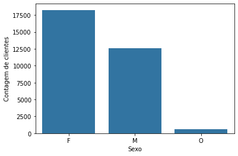

```python
cor_base = sns.color_palette()[0]
sns.countplot(data=df_cliente_clean, x='sexo', color=cor_base)
plt.xlabel('Sexo')
plt.ylabel('Contagem de clientes');
```

Podemos perceber uma dominância maior do sexo feminino no nosso dataset de clientes. Entretanto, não podemos afirmar que isso é representativo para a base como um todo, pois o dataset de Clientes veio com muitos valores ausentes para essa variável.

Agora vamos verificar como a variável de data de nascimento é distribuída no conjunto de dados, com especial atenção para o ano de nascimento.

```python
df_cliente_clean['ano_nascimento'] = df_cliente_clean.data_nascimento.dt.year
df_cliente_clean.head()
```

|  | id_cliente | sexo | data_nascimento | primeira_compra | ano_nascimento |
| --- | --- | --- | --- | --- | --- |
| 3 | 3 | F | 1984-09-13 | 2021-06-20 | 1984 |
| 5 | 5 | M | 1997-07-16 | 2021-06-20 | 1997 |
| 6 | 6 | M | 1990-10-27 | 2021-06-20 | 1990 |
| 7 | 7 | M | 1988-01-28 | 2021-06-20 | 1988 |
| 9 | 9 | M | 2000-01-01 | 2021-06-20 | 2000 |

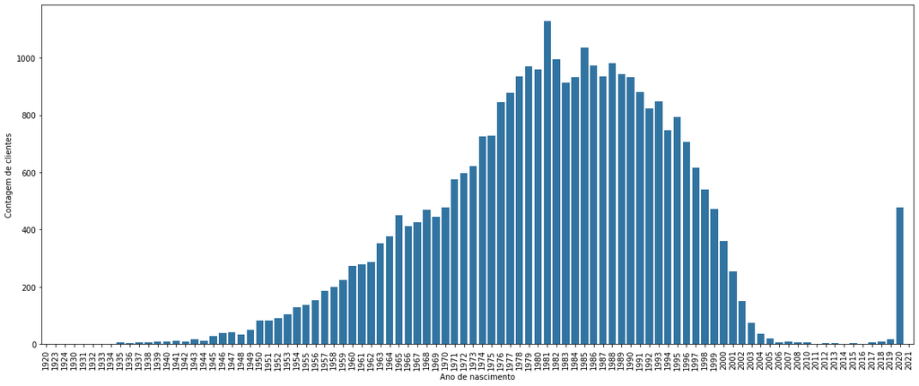

```python
plt.figure(figsize=[20,8])
sns.countplot(data=df_cliente_clean, x='ano_nascimento', color=cor_base)
plt.xticks(rotation=90)
plt.xlabel('Ano de nascimento')
plt.ylabel('Contagem de clientes');
```

Podemos percebemos que continuamos com alguns valores estranhos quando chegamos nos anos mais recentes, mesmo tendo já feito a limpeza do dataframe. Isso provavelmente aconteceu devido a algum erro no momento de cadastro desses valores. Entretanto, podemos perceber uma maior concentração de clientes entre os anos de 1976 até 1991, ou seja, de 45 até 30 anos. Novamente não podemos afirmar isso apenas com essa análise visual, pois a variável de data de nascimento estava muito suja.

Agora vamos verificar a variável de primeira compra, com especial atenção para o ano.

```python
df_cliente_clean['ano_primeira_compra'] = df_cliente_clean.primeira_compra.dt.year
df_cliente_clean.head()
```

|  | id_cliente | sexo | data_nascimento | primeira_compra | ano_nascimento | ano_primeira_compra |
| --- | --- | --- | --- | --- | --- | --- |
| 3 | 3 | F | 1984-09-13 | 2021-06-20 | 1984 | 2021 |
| 5 | 5 | M | 1997-07-16 | 2021-06-20 | 1997 | 2021 |
| 6 | 6 | M | 1990-10-27 | 2021-06-20 | 1990 | 2021 |
| 7 | 7 | M | 1988-01-28 | 2021-06-20 | 1988 | 2021 |
| 9 | 9 | M | 2000-01-01 | 2021-06-20 | 2000 | 2021 |

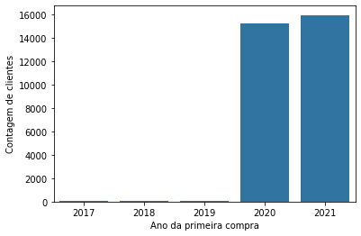

```python
sns.countplot(data=df_cliente_clean, x='ano_primeira_compra', color=cor_base)
plt.xlabel('Ano da primeira compra')
plt.ylabel('Contagem de clientes');
```

Para finalizar a análise do dataset de clientes, vamos verificar a distribuição das datas de primeira compra ao longo de 2020 e 2021.

```python
df_cliente_clean['mes_ano_primeira_compra'] = df_cliente_clean.primeira_compra.dt.to_period('M')
df_cliente_clean.head()
```

|  | id_cliente | sexo | data_nascimento | primeira_compra | ano_nascimento | ano_primeira_compra | mes_ano_primeira_compra |
| --- | --- | --- | --- | --- | --- | --- | --- |
| 3 | 3 | F | 1984-09-13 | 2021-06-20 | 1984 | 2021 | 2021-06 |
| 5 | 5 | M | 1997-07-16 | 2021-06-20 | 1997 | 2021 | 2021-06 |
| 6 | 6 | M | 1990-10-27 | 2021-06-20 | 1990 | 2021 | 2021-06 |
| 7 | 7 | M | 1988-01-28 | 2021-06-20 | 1988 | 2021 | 2021-06 |
| 9 | 9 | M | 2000-01-01 | 2021-06-20 | 2000 | 2021 | 2021-06 |

```python
df_cliente_clean_aux = df_cliente_clean.mes_ano_primeira_compra.value_counts().to_frame()
df_cliente_clean_aux.sort_index(inplace=True)
df_cliente_clean_aux.head()
```

|  | mes_ano_primeira_compra |
| --- | --- |
| 2017-04 | 5 |
| 2017-05 | 10 |
| 2017-06 | 6 |
| 2017-07 | 4 |
| 2017-08 | 3 |

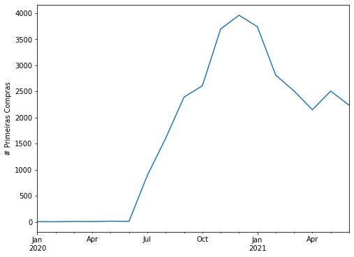

```python
df_cliente_clean_aux.loc['2020':].plot(figsize=[8,6], legend=False)
plt.ylabel('# Primeiras Compras');
```

#### Produtos

Para o dataset de Produtos, vamos começar analisando a variável de unidade.

```python
df_produto_clean.head()
```

|  | id_produto | unidade | nivel_1 | nivel_2 | nivel_3 | nivel_4 |
| --- | --- | --- | --- | --- | --- | --- |
| 0 | 0 | UN | NaN | NaN | NaN | NaN |
| 1 | 1 | UN | NaN | NaN | NaN | NaN |
| 2 | 2 | UN | NaN | NaN | NaN | NaN |
| 3 | 3 | UN | NaN | NaN | NaN | NaN |
| 4 | 4 | UN | NaN | NaN | NaN | NaN |

```python
df_produto_clean.unidade.value_counts()
```

```
UN    35871
PC      252
CX       45
DP       37
DS       23
SC       19
EA       12
FR        8
FD        7
CT        7
BA        5
PT        4
1         4
CR        3
KG        2
PE        2
MT        2
pc        2
DZ        1
PA        1
CJ        1
BS        1
KI        1
Name: unidade, dtype: int64
```

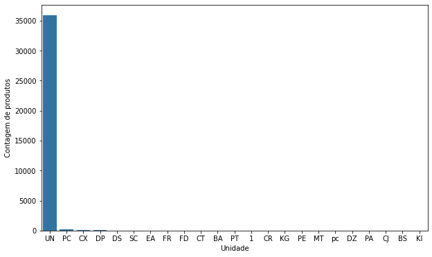

```python
plt.figure(figsize=[10,6])
col_ordem = df_produto_clean.unidade.value_counts().index
sns.countplot(data=df_produto_clean, x='unidade', color=cor_base, order=col_ordem)
plt.xlabel('Unidade')
plt.ylabel('Contagem de produtos');
```

Podemos observar que grande parte dos produtos possuem como unidade UN.

Para observar com mais detalhe as outras unidades, vamos desconsiderar a unidade UN na visualização.

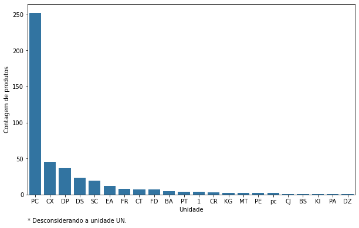

```python
plt.figure(figsize=[10,6])
col_ordem = df_produto_clean.query('unidade != "UN"').unidade.value_counts().index
sns.countplot(data=df_produto_clean.query('unidade != "UN"'), x='unidade', color=cor_base, order=col_ordem)
plt.xlabel('Unidade')
plt.ylabel('Contagem de produtos')
plt.annotate('* Desconsiderando a unidade UN.', (0,0), (0,-40), xycoords='axes fraction', textcoords='offset points', va='top');
```

Podemos observar que o segundo colcado é a unidade PC, mas que não chega nem perto do primeiro colocado (UN).

Para finalizar a análise do dataset de Produtos, vamos analisar o número de produtos para cada categoria em cada um dos quato níveis.

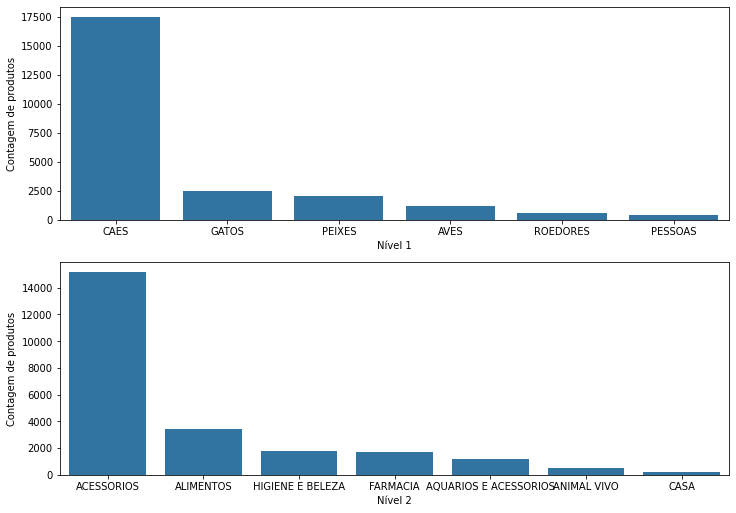

```python
colunas = ['nivel_1', 'nivel_2']
i = 1
plt.figure(figsize=[12,18])
for coluna in colunas:
    col_ordem = df_produto_clean[coluna].value_counts().index
    plt.subplot(4, 1, i)
    sns.countplot(data=df_produto_clean, x=coluna, color=cor_base, order=col_ordem)
    plt.xlabel(f'Nível {i}')
    plt.ylabel('Contagem de produtos')
    i += 1
```

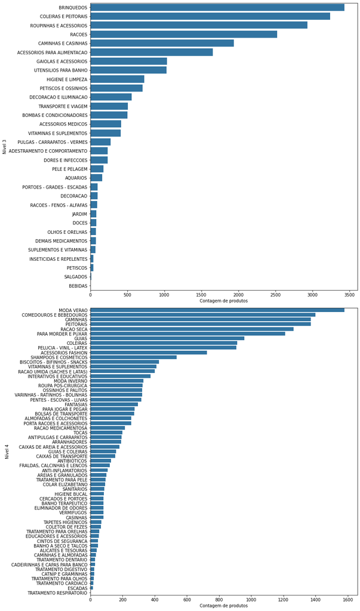

```python
colunas = ['nivel_3', 'nivel_4']
i = 1
plt.figure(figsize=[12,40], tight_layout =True)
for coluna in colunas:
    col_ordem = df_produto_clean[coluna].value_counts().index
    plt.subplot(4, 1, i)
    sns.countplot(data=df_produto_clean, y=coluna, color=cor_base, order=col_ordem)
    plt.ylabel(f'Nível {i+2}')
    plt.xlabel('Contagem de produtos')
    i += 1
```

Podemos observar que os produtos de categoria cão no nível 1 são os mais comuns dentre as possibilidades. Além disso, quando entramos no nível 2, percebemos que os acessórios correspondem a maior parte dos produtos.

Se aumentarmos ainda mais a granularidade das nossas categorias, observamos que os brinquedos no nível 3 e moda verão no nível 4 são as categorias de produtos mais comuns.

#### Vendas

Para o dataset de Vendas, vamos começar analisando a variável de quantidade.

```python
df_venda_clean.head()
```

|  | id_venda | data_venda | id_cliente | id_produto | quantidade | categoria_venda | id_venda_corrigido |
| --- | --- | --- | --- | --- | --- | --- | --- |
| 0 | 0 | 2021-02-10 | 46618 | 6669 | 1 | E-COMMERCE | 0466182021/02/10 |
| 1 | 0 | 2021-02-10 | 46618 | 7394 | 1 | E-COMMERCE | 0466182021/02/10 |
| 2 | 1 | 2021-02-12 | 70969 | 20460 | 1 | E-COMMERCE | 1709692021/02/12 |
| 3 | 2 | 2021-02-12 | 43436 | 7478 | 1 | E-COMMERCE | 2434362021/02/12 |
| 4 | 2 | 2021-02-12 | 43436 | 3198 | 1 | E-COMMERCE | 2434362021/02/12 |

```python
df_venda_clean.quantidade.describe().apply('{0:.3f}'.format)
```

```
count    1339440.000
mean           1.248
std            1.088
min            1.000
25%            1.000
50%            1.000
75%            1.000
max          102.000
Name: quantidade, dtype: object
```

```python
df_venda_grouped = df_venda_clean.groupby(['id_venda_corrigido', 'id_cliente'], as_index=False).quantidade.sum()
df_venda_grouped.head()
```

|  | id_venda_corrigido | id_cliente | quantidade |
| --- | --- | --- | --- |
| 0 | 0191752021/03/05 | 19175 | 2 |
| 1 | 0407312021/05/10 | 40731 | 1 |
| 2 | 0443852021/02/12 | 44385 | 3 |
| 3 | 0466182021/02/10 | 46618 | 2 |
| 4 | 0728482021/02/27 | 72848 | 3 |

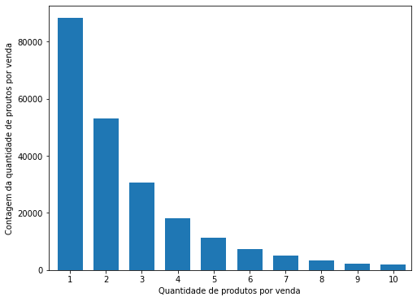

```python
bins_size = 1
bins = np.arange(0.5,df_venda_grouped.quantidade.max()+bins_size,bins_size)

plt.figure(figsize=[8,6])
plt.hist(data=df_venda_grouped, x='quantidade', bins=bins, rwidth=0.7)
plt.xticks(np.arange(0,11,1))
plt.xlim(0.4,10.5)
plt.xlabel('Quantidade de produtos por venda')
plt.ylabel('Contagem da quantidade de proutos por venda');
```

Podemos observar que a maior parte das vendas são unitárias.

Agora vamos descobrir o top 10 dos produtos mais vezes comprados, ou seja, não vamos verificar a quantidade, mas sim o número de vendas diferentes.

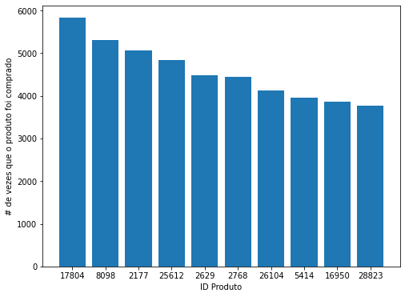

```python
top_10_produtos = df_venda_clean.id_produto.value_counts().head(10)
plt.figure(figsize=[8,6])
plt.bar(data=top_10_produtos, x=top_10_produtos.index, height=top_10_produtos.values)
plt.xlabel('ID Produto')
plt.ylabel('# de vezes que o produto foi comprado');
```

```python
df_produto_clean.loc[df_produto_clean.id_produto == '17804']
```

|  | id_produto | unidade | nivel_1 | nivel_2 | nivel_3 | nivel_4 |
| --- | --- | --- | --- | --- | --- | --- |
| 17804 | 17804 | UN | CAES | HIGIENE E BELEZA | HIGIENE E LIMPEZA | TAPETES HIGIENICOS |

Conseguimos observar que o produto com ID 17804 foi o produto mais vezes comprados. Ele é um produto de higiene para cães.

Depois disso, vamos verificar os clientes que mais vezes compraram na VAI Pet.

```python
df_venda_unica = df_venda_clean[['id_venda_corrigido', 'data_venda', 'id_cliente', 'categoria_venda']].copy()
df_venda_unica.drop_duplicates(inplace=True)
df_venda_unica.head()
```

|  | id_venda_corrigido | data_venda | id_cliente | categoria_venda |
| --- | --- | --- | --- | --- |
| 0 | 0466182021/02/10 | 2021-02-10 | 46618 | E-COMMERCE |
| 2 | 1709692021/02/12 | 2021-02-12 | 70969 | E-COMMERCE |
| 3 | 2434362021/02/12 | 2021-02-12 | 43436 | E-COMMERCE |
| 7 | 3709822021/02/12 | 2021-02-12 | 70982 | E-COMMERCE |
| 8 | 4714442021/02/15 | 2021-02-15 | 71444 | E-COMMERCE |

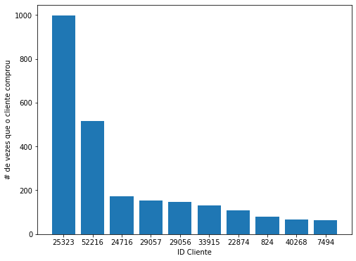

```python
top_10_clientes = df_venda_unica.id_cliente.value_counts().head(10)
plt.figure(figsize=[8,6])
plt.bar(data=top_10_clientes, x=top_10_clientes.index, height=top_10_clientes.values)
plt.xlabel('ID Cliente')
plt.ylabel('# de vezes que o cliente comprou');
```

Verificamos que o cliente que mais vezes comprou na VAI Pet é o de ID 25323.

A seguir, vamos analisar o número de vendas para cada categoria de venda, ou seja, venda física ou por e-commerce.

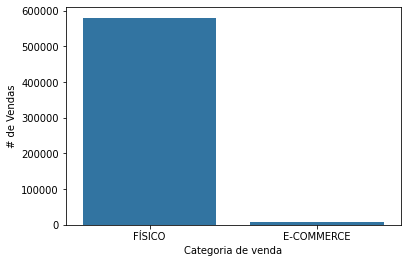

```python
col_ordem = df_venda_unica.categoria_venda.value_counts().index
sns.countplot(data=df_venda_unica, x='categoria_venda', color=cor_base, order=col_ordem)
plt.xlabel('Categoria de venda')
plt.ylabel('# de Vendas');
```

Como era de se esperar, uma vez que o CEO da VAI Pet já tinha nos informado, o número de vendas no canal físico é muito superior ao do e-commerce.

Para finalizar a análise do dataset de vendas, vamos verificar a distribuição das vendas ao longo de 2020 e 2021.

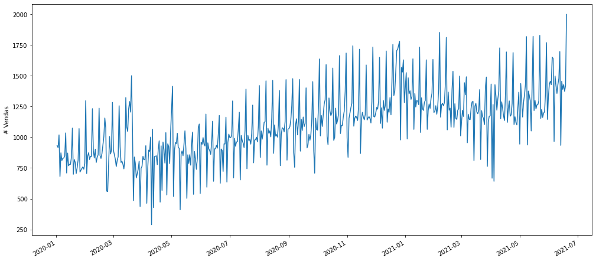

```python
df_venda_unica.data_venda.value_counts().to_frame().sort_index().plot(figsize=[17,8], legend=False)
plt.ylabel('# Vendas');
```

Podemos verificar uma redução nas vendas logo após março de 2020, muito provavelmente pela intensificação da pandemia. Entretanto, as vendas continuaram a crescer depois de alguns meses de baixa.

### 3.2. Análise Multivariada

Agora, vamos fazer a análise multivariada dos datasets. Primeiro, vamos verificar a relação da quantidade de produtos vendidos por categoria de venda, ou seja, venda física ou por e-commerce.

```python
df_quantidade_cat = df_venda_clean.groupby(['id_venda_corrigido','categoria_venda'], as_index=False).quantidade.sum()
df_quantidade_cat = df_quantidade_cat.loc[df_quantidade_cat.quantidade != 0]
df_quantidade_cat.head()
```

|  | id_venda_corrigido | categoria_venda | quantidade |
| --- | --- | --- | --- |
| 0 | 0191752021/03/05 | E-COMMERCE | 2 |
| 2 | 0407312021/05/10 | E-COMMERCE | 1 |
| 4 | 0443852021/02/12 | E-COMMERCE | 3 |
| 6 | 0466182021/02/10 | E-COMMERCE | 2 |
| 8 | 0728482021/02/27 | E-COMMERCE | 3 |

```python
df_categoria = df_quantidade_cat.groupby('categoria_venda').quantidade.agg(['sum', 'mean', 'std'])
df_categoria
```

| categoria_venda | sum | mean | std |
| --- | --- | --- | --- |
| E-COMMERCE | 15259 | 2.346816 | 3.569619 |
| FÍSICO | 1656972 | 2.853940 | 3.227705 |

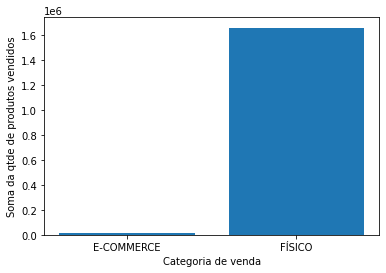

```python
plt.bar(data=df_categoria, x=[0,1], height='sum')
plt.xlabel('Categoria de venda')
plt.xticks([0,1], df_categoria.index)
plt.ylabel('Soma da qtde de produtos vendidos');
```

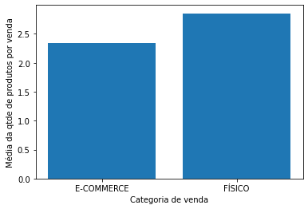

```python
plt.bar(data=df_categoria, x=[0,1], height='mean')
plt.xlabel('Categoria de venda')
plt.xticks([0,1], df_categoria.index)
plt.ylabel('Média da qtde de produtos por venda');
```

Apesar da quantidade total de produtos vendidos no modo físico ser muito maior do que pelo e-commerce, podemos observar que a média de produtos por venda não é tão distante, mas, ainda assim, o modo físico tem uma média maior por venda.

A seguir, vamos verificar a quantidade de produtos vendidos por cada categoria de produto, em cada um dos quatro níveis.

```python
df_venda_produto = pd.merge(df_venda_clean, df_produto_clean, on='id_produto')
df_venda_produto.head()
```

|  | id_venda | data_venda | id_cliente | id_produto | quantidade | categoria_venda | id_venda_corrigido | unidade | nivel_1 | nivel_2 | nivel_3 | nivel_4 |
| --- | --- | --- | --- | --- | --- | --- | --- | --- | --- | --- | --- | --- |
| 0 | 0 | 2021-02-10 | 46618 | 6669 | 1 | E-COMMERCE | 0466182021/02/10 | UN | CAES | ALIMENTOS | PETISCOS E OSSINHOS | BISCOITOS - BIFINHOS - SNACKS |
| 1 | 10998 | 2020-05-27 | 28214 | 6669 | 2 | FÍSICO | 10998282142020/05/27 | UN | CAES | ALIMENTOS | PETISCOS E OSSINHOS | BISCOITOS - BIFINHOS - SNACKS |
| 2 | 11135 | 2020-01-25 | NaN | 6669 | 1 | FÍSICO | 11135 | UN | CAES | ALIMENTOS | PETISCOS E OSSINHOS | BISCOITOS - BIFINHOS - SNACKS |
| 3 | 11659 | 2020-01-28 | NaN | 6669 | 1 | FÍSICO | 11659 | UN | CAES | ALIMENTOS | PETISCOS E OSSINHOS | BISCOITOS - BIFINHOS - SNACKS |
| 4 | 11847 | 2020-01-28 | NaN | 6669 | 1 | FÍSICO | 11847 | UN | CAES | ALIMENTOS | PETISCOS E OSSINHOS | BISCOITOS - BIFINHOS - SNACKS |

```python
def nivel_bar(df, x, y):
    """
    Plotar um gráfico de barra do nível do produto pela quantidade vendida.
    """
    if 'nivel' in x:
        nivel = x
        x_label = x.capitalize().replace('_', ' ')
        soma = y
        y_label = 'Total Produtos Vendidos'
    else:
        nivel = y
        y_label = y.capitalize().replace('_', ' ')
        soma = x
        x_label = 'Total Produtos Vendidos'

    df_aux = df.groupby(nivel, as_index=False).quantidade.sum()
    df_aux.sort_values(soma, ascending=False, inplace=True)

    sns.barplot(data=df_aux, x=x, y=y, color=cor_base)
    plt.xlabel(x_label)
    plt.ylabel(y_label)
```

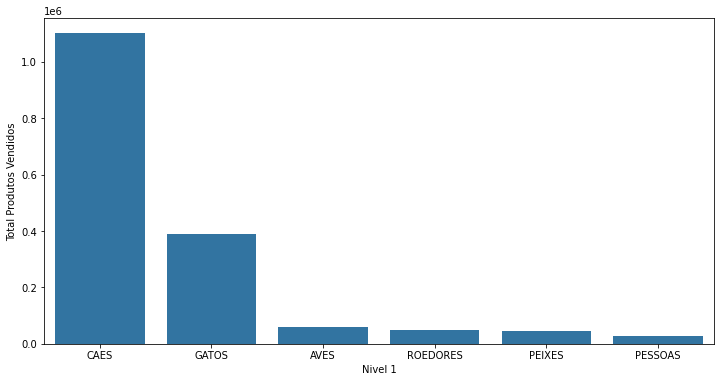

```python
plt.figure(figsize=[12,6])
nivel_bar(df_venda_produto, 'nivel_1', 'quantidade')
```

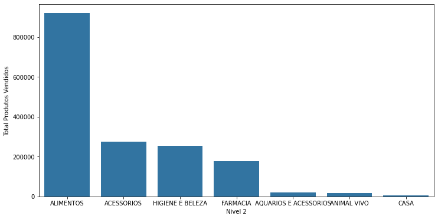

```python
plt.figure(figsize=[12,6])
nivel_bar(df_venda_produto, 'nivel_2', 'quantidade')
```

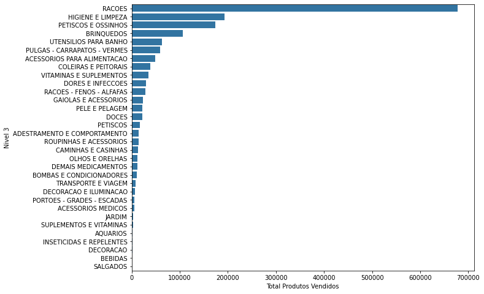

```python
plt.figure(figsize=[10,8])
nivel_bar(df_venda_produto, 'quantidade', 'nivel_3')
```

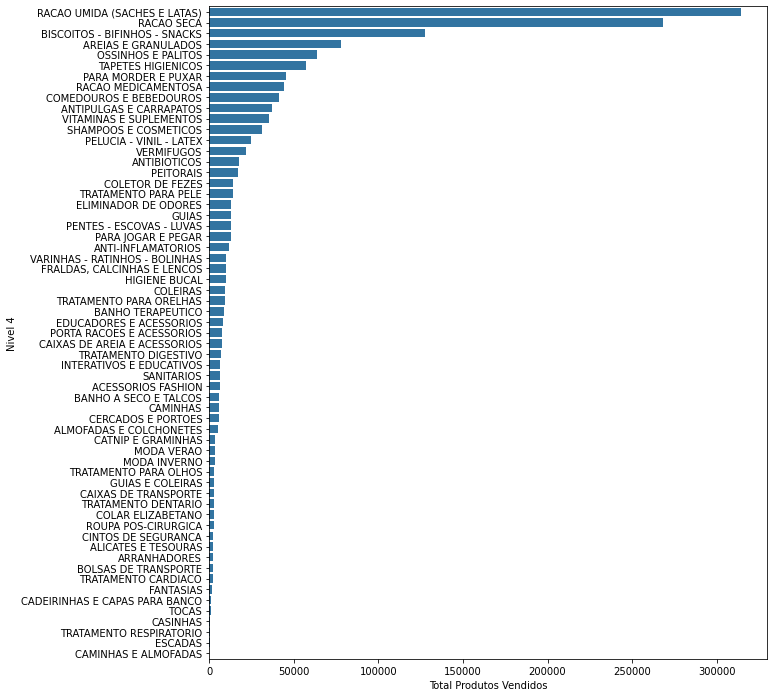

```python
plt.figure(figsize=[10,12])
nivel_bar(df_venda_produto, 'quantidade', 'nivel_4')
```

Conseguimos observar que as categorias mais populares de produtos são a de cão para o nível 1, alimentos para nível 2, rações para o nível 3 (com uma vantagem grande em comparação ao segundo colocado) e ração úmida no nível 4 (que tem a ver com a categoria do nível 3).

A seguir, vamos observar como a quantidade de produtos vendidos varia ao longo do tempo.

```python
df_venda_data = df_venda_produto.copy()
df_venda_data['ano_venda'] = df_venda_data.data_venda.dt.year
df_venda_data['mes_venda'] = df_venda_data.data_venda.dt.month
df_ate_maio = df_venda_data.loc[(df_venda_data.mes_venda <= 5)].copy()
```

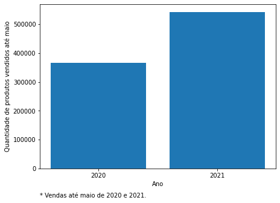

```python
plt.figure(figsize=[7, 5])
plt.bar(data=df_ate_maio.groupby('ano_venda', as_index=False).quantidade.sum(), x='ano_venda', height='quantidade')
plt.xlabel('Ano')
plt.xticks([2020, 2021])
plt.ylabel('Quantidade de produtos vendidos até maio')
plt.annotate('* Vendas até maio de 2020 e 2021.', (0,0), (0,-40), xycoords='axes fraction', textcoords='offset points', va='top');
```

Considerando as vendas até maio de 2020 e 2021, conseguimos perceber um aumento nas vendas no primeiro semestre de 2021 em relação ao primeiro semestre de 2020.

Agora, vamos verificarmos a quantidade total de vendas.

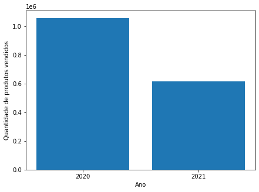

```python
plt.figure(figsize=[7, 5])
plt.bar(data=df_venda_data.groupby('ano_venda', as_index=False).quantidade.sum(), x='ano_venda', height='quantidade')
plt.xlabel('Ano')
plt.xticks([2020, 2021])
plt.ylabel('Quantidade de produtos vendidos');
```

Como era de se esperar, as vendas de 2020 foram superiores até metade de 2021.

Agora, vamos ver a quantidade de produtos vendidos ao longo dos meses.

```python
df_venda_data['ano_mes_venda'] = df_venda_data.data_venda.dt.to_period('M')
df_venda_ano_mes = df_venda_data.groupby('ano_mes_venda').quantidade.sum()
df_venda_ano_mes = df_venda_ano_mes.loc[:'2021-05']
```

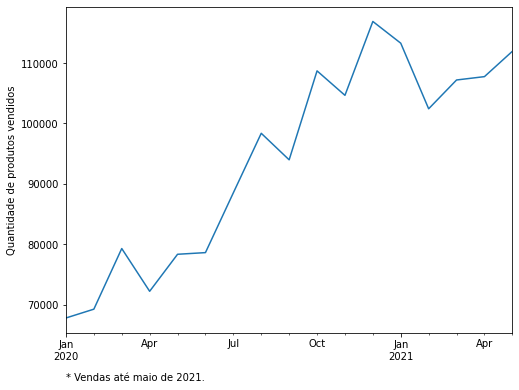

```python
plt.figure(figsize=[8,6])
df_venda_ano_mes.plot()
plt.xlabel('')
plt.ylabel('Quantidade de produtos vendidos')
plt.annotate('* Vendas até maio de 2021.', (0,0), (0,-40), xycoords='axes fraction', textcoords='offset points', va='top');
```

Novamente conseguimos verificar uma tendência de crescimento das vendas de 2020 até 2021.

E, agora, vamos olhar a quantidade de produtos vendidos por dia.

```python
df_venda_dia = df_venda_data.groupby('data_venda').quantidade.sum()
```

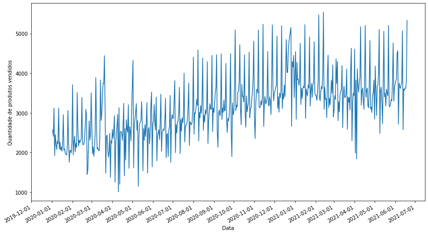

```python
plt.figure(figsize=[14,8])
df_venda_dia.plot()
plt.xlabel('Data')
plt.xticks(np.arange(df_venda_data.ano_mes_venda.min()-1, df_venda_data.ano_mes_venda.max()+2, dtype='datetime64[M]'))
plt.ylabel('Quantidade de produtos vendidos');
```

Observamos novamente a tendência de crescimento, mas também conseguimos observar uma sazonalidade por semana.

A seguir vamos calcular as médias móveis de 3, 7 e 14 dias.

```python
df_venda_dia = df_venda_dia.to_frame()
df_venda_dia = df_venda_dia.asfreq('D', fill_value=0)
df_venda_dia.head()
```

| data_venda | quantidade |
| --- | --- |
| 2020-01-02 | 2568 |
| 2020-01-03 | 2408 |
| 2020-01-04 | 3119 |
| 2020-01-05 | 1925 |
| 2020-01-06 | 2455 |

```python
df_venda_dia['media_3'] = df_venda_dia.quantidade.rolling(window=3).mean()
df_venda_dia['media_7'] = df_venda_dia.quantidade.rolling(window=7).mean()
df_venda_dia['media_14'] = df_venda_dia.quantidade.rolling(window=14).mean()
```

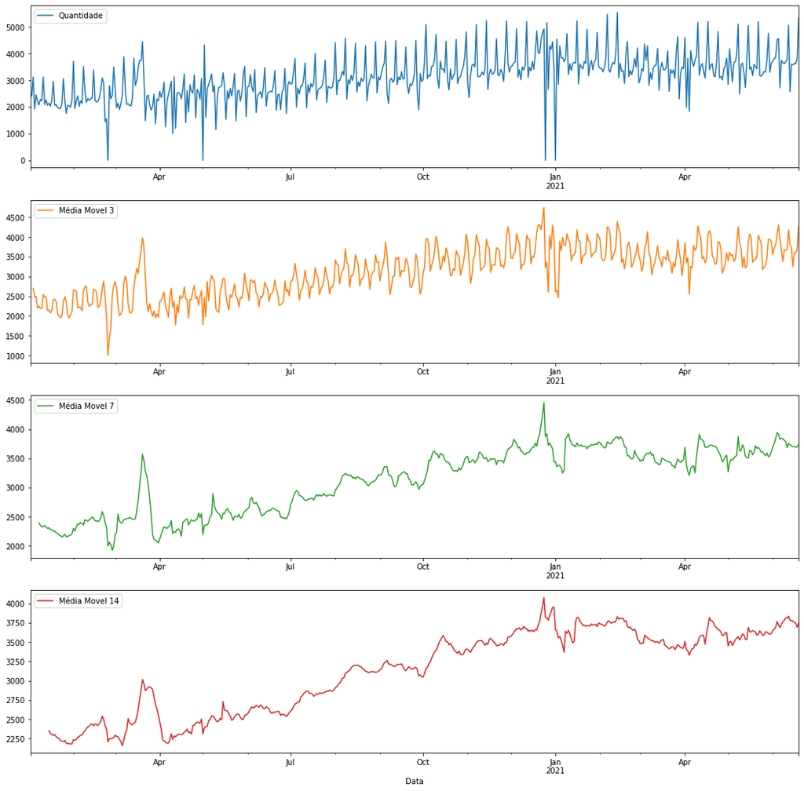

```python
axes = df_venda_dia[['quantidade', 'media_3', 'media_7', 'media_14']].plot(figsize=[18,18], subplots=True, sharex=False,xlabel='')
plt.xlabel('Data')
i = 0
for legenda in ['Quantidade','Média Movel 3','Média Movel 7','Média Movel 14']:
    axes[i].legend(labels=[legenda,], loc=2)
    i += 1
```

As médias móveis serviram para suavizar o gráfico de quantidades de produtos vendidos por dia, e deixar claro a tendência de crescimento. Vale destacar que logo no início de março de 2020 tivemos um aumento na média de produtos vendidos, mas que ao chegar próximo de abril a média cai abruptamente. Isso provavelmente deve-se ao aviso de quarentena (aumento nas compras), que logo caíram quando a quarentena de fato começou.

Depois disso, vamos verificar a representatividade de clientes novos e antigos na quantidade de produtos vendidos.

```python
df_cliente_venda = df_venda_data.dropna(subset=['id_cliente']).copy()
df_cliente_venda = df_cliente_venda[['id_venda_corrigido', 'data_venda', 'ano_mes_venda', 'id_cliente', 'quantidade']]
df_cliente_venda = df_cliente_venda.groupby(['id_venda_corrigido', 'data_venda', 'ano_mes_venda', 'id_cliente'], as_index=False).quantidade.sum()
df_cliente_venda = df_cliente_venda.sort_values('data_venda')
df_cliente_venda.head()
```

|  | id_venda_corrigido | data_venda | ano_mes_venda | id_cliente | quantidade |
| --- | --- | --- | --- | --- | --- |
| 118465 | 364456196722020/01/02 | 2020-01-02 | 2020-01 | 19672 | 1 |
| 52653 | 173750122262020/01/02 | 2020-01-02 | 2020-01 | 12226 | 1 |
| 72095 | 23241302302020/01/02 | 2020-01-02 | 2020-01 | 30230 | 8 |
| 70956 | 228027299072020/01/02 | 2020-01-02 | 2020-01 | 29907 | 1 |
| 70333 | 220966304812020/01/02 | 2020-01-02 | 2020-01 | 30481 | 2 |

```python
def ordem_compra_cliente(dict_cliente, cliente):
    """
    Ordena a compra de um cliente.

    """
    if cliente in dict_cliente:
        dict_cliente[cliente] += 1
    else:
        dict_cliente[cliente] = 1

    return dict_cliente[cliente]
```

```python
# Adicionar coluna com a ordem de compra do cliente. O df precisa estar ordenado pela data de venda
cliente_cont = {}
df_cliente_venda['ordem_cliente'] = [ordem_compra_cliente(cliente_cont, cliente) for cliente in df_cliente_venda.id_cliente]
df_cliente_venda.head()
```

|  | id_venda_corrigido | data_venda | ano_mes_venda | id_cliente | quantidade | ordem_cliente |
| --- | --- | --- | --- | --- | --- | --- |
| 118465 | 364456196722020/01/02 | 2020-01-02 | 2020-01 | 19672 | 1 | 1 |
| 52653 | 173750122262020/01/02 | 2020-01-02 | 2020-01 | 12226 | 1 | 1 |
| 72095 | 23241302302020/01/02 | 2020-01-02 | 2020-01 | 30230 | 8 | 1 |
| 70956 | 228027299072020/01/02 | 2020-01-02 | 2020-01 | 29907 | 1 | 1 |
| 70333 | 220966304812020/01/02 | 2020-01-02 | 2020-01 | 30481 | 2 | 1 |

```python
# Criar uma coluna em df_order_grouped para mostrar se foi a primeira compra do cliente
df_cliente_venda['primeira_compra'] = [True if ordem == 1 else False for ordem in df_cliente_venda.ordem_cliente]
df_cliente_venda.head()
```

|  | id_venda_corrigido | data_venda | ano_mes_venda | id_cliente | quantidade | ordem_cliente | primeira_compra |
| --- | --- | --- | --- | --- | --- | --- | --- |
| 118465 | 364456196722020/01/02 | 2020-01-02 | 2020-01 | 19672 | 1 | 1 | True |
| 52653 | 173750122262020/01/02 | 2020-01-02 | 2020-01 | 12226 | 1 | 1 | True |
| 72095 | 23241302302020/01/02 | 2020-01-02 | 2020-01 | 30230 | 8 | 1 | True |
| 70956 | 228027299072020/01/02 | 2020-01-02 | 2020-01 | 29907 | 1 | 1 | True |
| 70333 | 220966304812020/01/02 | 2020-01-02 | 2020-01 | 30481 | 2 | 1 | True |

```python
df_novos_clientes = df_cliente_venda.groupby(['ano_mes_venda', 'primeira_compra']).quantidade.agg(['sum', 'count']).reset_index()
df_novos_clientes.ano_mes_venda = df_novos_clientes.ano_mes_venda.astype(str)
df_novos_clientes = df_novos_clientes.loc[df_novos_clientes.ano_mes_venda != '2021-06']
df_novos_clientes.head()
```

|  | ano_mes_venda | primeira_compra | sum | count |
| --- | --- | --- | --- | --- |
| 0 | 2020-01 | False | 289 | 139 |
| 1 | 2020-01 | True | 1058 | 431 |
| 2 | 2020-02 | False | 625 | 240 |
| 3 | 2020-02 | True | 831 | 348 |
| 4 | 2020-03 | False | 947 | 375 |

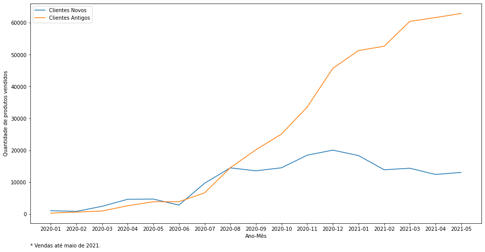

```python
plt.figure(figsize=[16,8])
plt.errorbar(data=df_novos_clientes.query('primeira_compra'), x='ano_mes_venda', y='sum', label='Clientes Novos')
plt.errorbar(data=df_novos_clientes.query('~primeira_compra'), x='ano_mes_venda', y='sum', label='Clientes Antigos')
plt.xlabel('Ano-Mês')
plt.ylabel('Quantidade de produtos vendidos')
plt.legend()
plt.annotate('* Vendas até maio de 2021.', (0,0), (0,-40), xycoords='axes fraction', textcoords='offset points', va='top');
```

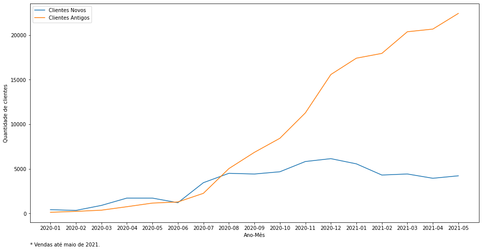

```python
plt.figure(figsize=[16,8])
plt.errorbar(data=df_novos_clientes.query('primeira_compra'), x='ano_mes_venda', y='count', label='Clientes Novos')
plt.errorbar(data=df_novos_clientes.query('~primeira_compra'), x='ano_mes_venda', y='count', label='Clientes Antigos')
plt.xlabel('Ano-Mês')
plt.ylabel('Quantidade de clientes')
plt.legend()
plt.annotate('* Vendas até maio de 2021.', (0,0), (0,-40), xycoords='axes fraction', textcoords='offset points', va='top');
```

Podemos observar que os dois gráficos são bem parecidos, com a quantidade de produtos vendidos para clientes novos e quantidade de clientes novos ficando na frente dos antigos em boa parte de 2020, mas que são ultrapassados pelas linhas dos antigos em agosto de 2020 para nunca mais ficar atrás.

Para finalizar a EDA, vamos observar como é a distribuição do tempo em dias entre compras consecutivas de um mesmo cliente.

```python
df_cliente_venda = df_cliente_venda.sort_values(['id_cliente', 'data_venda']).reset_index(drop=True)
df_cliente_venda.head(10)
```

|  | id_venda_corrigido | data_venda | ano_mes_venda | id_cliente | quantidade | ordem_cliente | primeira_compra |
| --- | --- | --- | --- | --- | --- | --- | --- |
| 0 | 1930911002020/09/11 | 2020-09-11 | 2020-09 | 100 | 14 | 1 | True |
| 1 | 118401100022020/11/18 | 2020-11-18 | 2020-11 | 10002 | 1 | 1 | True |
| 2 | 101493100022021/01/13 | 2021-01-13 | 2021-01 | 10002 | 1 | 2 | False |
| 3 | 146171100022021/03/03 | 2021-03-03 | 2021-03 | 10002 | 2 | 3 | False |
| 4 | 269420100052020/10/07 | 2020-10-07 | 2020-10 | 10005 | 7 | 1 | True |
| 5 | 230770100052020/11/17 | 2020-11-17 | 2020-11 | 10005 | 6 | 2 | False |
| 6 | 201312100052020/11/24 | 2020-11-24 | 2020-11 | 10005 | 5 | 3 | False |
| 7 | 273491100052020/12/02 | 2020-12-02 | 2020-12 | 10005 | 11 | 4 | False |
| 8 | 210966100052021/02/09 | 2021-02-09 | 2021-02 | 10005 | 4 | 5 | False |
| 9 | 213355100052021/02/28 | 2021-02-28 | 2021-02 | 10005 | 3 | 6 | False |

```python
df_cliente_venda['ultima_compra'] = df_cliente_venda.data_venda.shift()
df_cliente_venda.loc[df_cliente_venda.primeira_compra, 'ultima_compra'] = df_cliente_venda.loc[df_cliente_venda.primeira_compra, 'data_venda']
df_cliente_venda.head(10)
```

|  | id_venda_corrigido | data_venda | ano_mes_venda | id_cliente | quantidade | ordem_cliente | primeira_compra | ultima_compra |
| --- | --- | --- | --- | --- | --- | --- | --- | --- |
| 0 | 1930911002020/09/11 | 2020-09-11 | 2020-09 | 100 | 14 | 1 | True | 2020-09-11 |
| 1 | 118401100022020/11/18 | 2020-11-18 | 2020-11 | 10002 | 1 | 1 | True | 2020-11-18 |
| 2 | 101493100022021/01/13 | 2021-01-13 | 2021-01 | 10002 | 1 | 2 | False | 2020-11-18 |
| 3 | 146171100022021/03/03 | 2021-03-03 | 2021-03 | 10002 | 2 | 3 | False | 2021-01-13 |
| 4 | 269420100052020/10/07 | 2020-10-07 | 2020-10 | 10005 | 7 | 1 | True | 2020-10-07 |
| 5 | 230770100052020/11/17 | 2020-11-17 | 2020-11 | 10005 | 6 | 2 | False | 2020-10-07 |
| 6 | 201312100052020/11/24 | 2020-11-24 | 2020-11 | 10005 | 5 | 3 | False | 2020-11-17 |
| 7 | 273491100052020/12/02 | 2020-12-02 | 2020-12 | 10005 | 11 | 4 | False | 2020-11-24 |
| 8 | 210966100052021/02/09 | 2021-02-09 | 2021-02 | 10005 | 4 | 5 | False | 2020-12-02 |
| 9 | 213355100052021/02/28 | 2021-02-28 | 2021-02 | 10005 | 3 | 6 | False | 2021-02-09 |

```python
df_cliente_venda['dias_entre_compras'] = (df_cliente_venda.data_venda - df_cliente_venda.ultima_compra).dt.days
df_cliente_venda.head(10)
```

|  | id_venda_corrigido | data_venda | ano_mes_venda | id_cliente | quantidade | ordem_cliente | primeira_compra | ultima_compra | dias_entre_compras |
| --- | --- | --- | --- | --- | --- | --- | --- | --- | --- |
| 0 | 1930911002020/09/11 | 2020-09-11 | 2020-09 | 100 | 14 | 1 | True | 2020-09-11 | 0 |
| 1 | 118401100022020/11/18 | 2020-11-18 | 2020-11 | 10002 | 1 | 1 | True | 2020-11-18 | 0 |
| 2 | 101493100022021/01/13 | 2021-01-13 | 2021-01 | 10002 | 1 | 2 | False | 2020-11-18 | 56 |
| 3 | 146171100022021/03/03 | 2021-03-03 | 2021-03 | 10002 | 2 | 3 | False | 2021-01-13 | 49 |
| 4 | 269420100052020/10/07 | 2020-10-07 | 2020-10 | 10005 | 7 | 1 | True | 2020-10-07 | 0 |
| 5 | 230770100052020/11/17 | 2020-11-17 | 2020-11 | 10005 | 6 | 2 | False | 2020-10-07 | 41 |
| 6 | 201312100052020/11/24 | 2020-11-24 | 2020-11 | 10005 | 5 | 3 | False | 2020-11-17 | 7 |
| 7 | 273491100052020/12/02 | 2020-12-02 | 2020-12 | 10005 | 11 | 4 | False | 2020-11-24 | 8 |
| 8 | 210966100052021/02/09 | 2021-02-09 | 2021-02 | 10005 | 4 | 5 | False | 2020-12-02 | 69 |
| 9 | 213355100052021/02/28 | 2021-02-28 | 2021-02 | 10005 | 3 | 6 | False | 2021-02-09 | 19 |

```python
df_cliente_venda.describe()
```

|  | quantidade | ordem_cliente | dias_entre_compras |
| --- | --- | --- | --- |
| count | 228475.000000 | 228475.000000 | 228475.000000 |
| mean | 2.962477 | 7.894557 | 25.058492 |
| std | 3.363585 | 40.801465 | 41.668069 |
| min | 1.000000 | 1.000000 | 0.000000 |
| 25% | 1.000000 | 1.000000 | 0.000000 |
| 50% | 2.000000 | 3.000000 | 11.000000 |
| 75% | 3.000000 | 6.000000 | 31.000000 |
| max | 123.000000 | 997.000000 | 522.000000 |

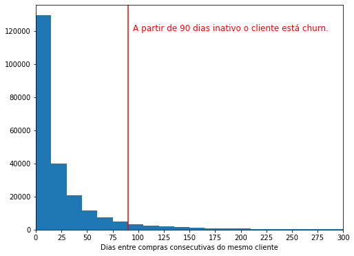

```python
bin_size = 15
bins = np.arange(0,df_cliente_venda.dias_entre_compras.max()+bin_size,bin_size)

plt.figure(figsize=[8,6])
plt.hist(data=df_cliente_venda, x='dias_entre_compras', bins=bins)
plt.xlim(0,300)
plt.xticks(np.arange(0, 301, 25))
plt.xlabel('Dias entre compras consecutivas do mesmo cliente')
plt.axvline(x=90, c='r')
plt.text(x=95, y=12e4, s='A partir de 90 dias inativo o cliente está churn.', fontdict={'c': 'r', 'fontsize': 12});
```

A partir do histograma anterior, podemos observar que grande parte dos dias entre vendas consecutivas para um mesmo cliente é menor que 90 dias, desconsiderando o fato da última compra de um cliente não estar sendo considerada no gráfico, pois não possui uma data para próxima compra.

## 4. Análise de churn e retenção de clientes

### 4.1. Feature Engineering

Vamos criar a nossa base mestre, ou seja, um dataframe consolidando as informações. Primeiro, vamos determinar os clientes que estão churn. Para isso, vamos considerar que um cliente está churn quando possui 90 dias da última compra. Entretanto, para essa consideração, vamos considerar apenas os clientes que tem pelo menos 90 dias da primeira compra em relação a data de referência.

```python
df_venda_sem_nan = df_venda_clean.dropna().copy()
```

```python
# Última data no dataframe de vendas
ultima_data_vendas = df_venda_sem_nan.data_venda.max()
ultima_data_vendas
```

```
Timestamp('2021-06-19 00:00:00')
```

```python
# Data de referência (90 dias da última data registrada na base de vendas) para determinar se os clientes estão churn
data_referencia = ultima_data_vendas - datetime.timedelta(days=90)
data_referencia
```

```
Timestamp('2021-03-21 00:00:00')
```

```python
# Dataframe para filtrar os clientes com um compra pelo menos 90 dias antes da data de referência
df_cliente_primeira_compra = df_venda_sem_nan.groupby('id_cliente', as_index=False).data_venda.min()
df_cliente_primeira_compra.rename({'data_venda': 'data_primeira_compra'}, axis=1, inplace=True)
df_cliente_primeira_compra.head()
```

|  | id_cliente | data_primeira_compra |
| --- | --- | --- |
| 0 | 100 | 2020-09-11 |
| 1 | 10002 | 2020-11-18 |
| 2 | 10005 | 2020-10-07 |
| 3 | 10006 | 2020-03-24 |
| 4 | 10008 | 2020-11-02 |

```python
df_cliente_primeira_compra['dias_referencia_primeira_compra'] = (data_referencia - df_cliente_primeira_compra.data_primeira_compra).dt.days
df_cliente_primeira_compra.head()
```

|  | id_cliente | data_primeira_compra | dias_referencia_primeira_compra |
| --- | --- | --- | --- |
| 0 | 100 | 2020-09-11 | 191 |
| 1 | 10002 | 2020-11-18 | 123 |
| 2 | 10005 | 2020-10-07 | 165 |
| 3 | 10006 | 2020-03-24 | 362 |
| 4 | 10008 | 2020-11-02 | 139 |

```python
df_cliente_primeira_compra = df_cliente_primeira_compra.loc[df_cliente_primeira_compra.dias_referencia_primeira_compra > 90]
df_cliente_primeira_compra.head()
```

|  | id_cliente | data_primeira_compra | dias_referencia_primeira_compra |
| --- | --- | --- | --- |
| 0 | 100 | 2020-09-11 | 191 |
| 1 | 10002 | 2020-11-18 | 123 |
| 2 | 10005 | 2020-10-07 | 165 |
| 3 | 10006 | 2020-03-24 | 362 |
| 4 | 10008 | 2020-11-02 | 139 |

```python
df_depois_referencia = df_venda_sem_nan.loc[df_venda_sem_nan.data_venda > data_referencia]
```

```python
# Dataframe com a última data de compra por cliente no dataset de venda
df_cliente_depois = df_depois_referencia.groupby('id_cliente', as_index=False).data_venda.min()
df_cliente_depois.rename({'data_venda': 'data_depois'}, axis=1, inplace=True)
df_cliente_depois.head()
```

|  | id_cliente | data_depois |
| --- | --- | --- |
| 0 | 10005 | 2021-04-30 |
| 1 | 10008 | 2021-05-20 |
| 2 | 10009 | 2021-06-16 |
| 3 | 1001 | 2021-04-07 |
| 4 | 10010 | 2021-04-14 |

```python
df_cliente_depois['dias_referencia_depois'] = (df_cliente_depois.data_depois - data_referencia).dt.days
df_cliente_depois.head()
```

|  | id_cliente | data_depois | dias_referencia_depois |
| --- | --- | --- | --- |
| 0 | 10005 | 2021-04-30 | 40 |
| 1 | 10008 | 2021-05-20 | 60 |
| 2 | 10009 | 2021-06-16 | 87 |
| 3 | 1001 | 2021-04-07 | 17 |
| 4 | 10010 | 2021-04-14 | 24 |

```python
df_antes_referencia = df_venda_sem_nan.loc[df_venda_sem_nan.data_venda <= data_referencia]
```

```python
# Dataframe com a última data de compra por cliente no dataset de venda em relação a data de referência
df_cliente_antes = df_antes_referencia.groupby('id_cliente', as_index=False).data_venda.max()
df_cliente_antes.rename({'data_venda': 'data_antes'}, axis=1, inplace=True)
df_cliente_antes.head()
```

|  | id_cliente | data_antes |
| --- | --- | --- |
| 0 | 100 | 2020-09-11 |
| 1 | 10002 | 2021-03-03 |
| 2 | 10005 | 2021-02-28 |
| 3 | 10006 | 2020-03-24 |
| 4 | 10008 | 2021-02-01 |

```python
df_cliente_antes['dias_referencia_antes'] = (data_referencia - df_cliente_antes.data_antes).dt.days
df_cliente_antes.head()
```

|  | id_cliente | data_antes | dias_referencia_antes |
| --- | --- | --- | --- |
| 0 | 100 | 2020-09-11 | 191 |
| 1 | 10002 | 2021-03-03 | 18 |
| 2 | 10005 | 2021-02-28 | 21 |
| 3 | 10006 | 2020-03-24 | 362 |
| 4 | 10008 | 2021-02-01 | 48 |

```python
df_master = pd.merge(df_cliente_antes, df_cliente_depois, on='id_cliente', how='left')
df_master.dias_referencia_depois = df_master.dias_referencia_depois.fillna(90)
df_master['dias_entre_antes_depois'] = (df_master.dias_referencia_depois + df_master.dias_referencia_antes).astype(int)
df_master.drop(['data_depois', 'dias_referencia_depois'], axis=1, inplace=True)
df_master.rename({'data_antes': 'ultima_compra'}, axis=1, inplace=True)
df_master.head()
```

|  | id_cliente | ultima_compra | dias_referencia_antes | dias_entre_antes_depois |
| --- | --- | --- | --- | --- |
| 0 | 100 | 2020-09-11 | 191 | 281 |
| 1 | 10002 | 2021-03-03 | 18 | 108 |
| 2 | 10005 | 2021-02-28 | 21 | 61 |
| 3 | 10006 | 2020-03-24 | 362 | 452 |
| 4 | 10008 | 2021-02-01 | 48 | 108 |

```python
df_master['churn'] = [1 if dias > 90 else 0 for dias in df_master.dias_entre_antes_depois]
df_master.drop('dias_entre_antes_depois', axis=1, inplace=True)
df_master.head()
```

|  | id_cliente | ultima_compra | dias_referencia_antes | churn |
| --- | --- | --- | --- | --- |
| 0 | 100 | 2020-09-11 | 191 | 1 |
| 1 | 10002 | 2021-03-03 | 18 | 1 |
| 2 | 10005 | 2021-02-28 | 21 | 0 |
| 3 | 10006 | 2020-03-24 | 362 | 1 |
| 4 | 10008 | 2021-02-01 | 48 | 1 |

```python
# Filtrondo apenas os clientes com mais de 90 dias de compra em relação a data de referência
df_master = pd.merge(df_master, df_cliente_primeira_compra, on='id_cliente', how='right')
df_master.drop('data_primeira_compra', axis=1, inplace=True)
df_master.head()
```

|  | id_cliente | ultima_compra | dias_referencia_antes | churn | dias_referencia_primeira_compra |
| --- | --- | --- | --- | --- | --- |
| 0 | 100 | 2020-09-11 | 191 | 1 | 191 |
| 1 | 10002 | 2021-03-03 | 18 | 1 | 123 |
| 2 | 10005 | 2021-02-28 | 21 | 0 | 165 |
| 3 | 10006 | 2020-03-24 | 362 | 1 | 362 |
| 4 | 10008 | 2021-02-01 | 48 | 1 | 139 |

Agora, vamos adicionar a nossa base mestre a quantidade de podutos vendidos para cada cliente.

```python
df_quantidade_venda = df_antes_referencia.groupby(['id_cliente', 'id_venda_corrigido'], as_index=False).quantidade.sum()
df_quantidade_venda.head()
```

|  | id_cliente | id_venda_corrigido | quantidade |
| --- | --- | --- | --- |
| 0 | 100 | 1930911002020/09/11 | 14 |
| 1 | 10002 | 101493100022021/01/13 | 1 |
| 2 | 10002 | 118401100022020/11/18 | 1 |
| 3 | 10002 | 146171100022021/03/03 | 2 |
| 4 | 10005 | 201312100052020/11/24 | 5 |

```python
df_cliente_produto = df_quantidade_venda.groupby('id_cliente').quantidade.agg(['sum', 'max', 'min', 'mean']).reset_index()
df_cliente_produto = df_cliente_produto.rename({'sum': 'soma_produtos',
                                                'max': 'max_produtos_venda',
                                                'min': 'min_produtos_venda',
                                                'mean': 'media_produtos_venda'}, axis=1)
df_cliente_produto.head()
```

|  | id_cliente | soma_produtos | max_produtos_venda | min_produtos_venda | media_produtos_venda |
| --- | --- | --- | --- | --- | --- |
| 0 | 100 | 14 | 14 | 14 | 14.000000 |
| 1 | 10002 | 4 | 2 | 1 | 1.333333 |
| 2 | 10005 | 41 | 11 | 3 | 5.857143 |
| 3 | 10006 | 1 | 1 | 1 | 1.000000 |
| 4 | 10008 | 4 | 1 | 1 | 1.000000 |

```python
df_master = pd.merge(df_master, df_cliente_produto, on='id_cliente', how='left')
df_master.head()
```

|  | id_cliente | ultima_compra | dias_referencia_antes | churn | dias_referencia_primeira_compra | soma_produtos | max_produtos_venda | min_produtos_venda | media_produtos_venda |
| --- | --- | --- | --- | --- | --- | --- | --- | --- | --- |
| 0 | 100 | 2020-09-11 | 191 | 1 | 191 | 14 | 14 | 14 | 14.000000 |
| 1 | 10002 | 2021-03-03 | 18 | 1 | 123 | 4 | 2 | 1 | 1.333333 |
| 2 | 10005 | 2021-02-28 | 21 | 0 | 165 | 41 | 11 | 3 | 5.857143 |
| 3 | 10006 | 2020-03-24 | 362 | 1 | 362 | 1 | 1 | 1 | 1.000000 |
| 4 | 10008 | 2021-02-01 | 48 | 1 | 139 | 4 | 1 | 1 | 1.000000 |

Agora vamos calcular algumas métricas para os dias entre compras consecutivas, além de calcular o número de compras de cada cliente. Para isso, vamos usar o dataframe `df_cliente_venda`, criado na parte de EDA, mas antes precisamos filtrar para as datas de venda anteriores a data de referência.

```python
df_cliente_venda_referencia = df_cliente_venda.loc[df_cliente_venda.data_venda < data_referencia]
df_cliente_venda_referencia.head()
```

|  | id_venda_corrigido | data_venda | ano_mes_venda | id_cliente | quantidade | ordem_cliente | primeira_compra | ultima_compra | dias_entre_compras |
| --- | --- | --- | --- | --- | --- | --- | --- | --- | --- |
| 0 | 1930911002020/09/11 | 2020-09-11 | 2020-09 | 100 | 14 | 1 | True | 2020-09-11 | 0 |
| 1 | 118401100022020/11/18 | 2020-11-18 | 2020-11 | 10002 | 1 | 1 | True | 2020-11-18 | 0 |
| 2 | 101493100022021/01/13 | 2021-01-13 | 2021-01 | 10002 | 1 | 2 | False | 2020-11-18 | 56 |
| 3 | 146171100022021/03/03 | 2021-03-03 | 2021-03 | 10002 | 2 | 3 | False | 2021-01-13 | 49 |
| 4 | 269420100052020/10/07 | 2020-10-07 | 2020-10 | 10005 | 7 | 1 | True | 2020-10-07 | 0 |

```python
df_cliente_venda_grouped = df_cliente_venda_referencia.groupby('id_cliente').dias_entre_compras.agg(['count', 'sum', 'max', 'min', 'mean']).reset_index()
df_cliente_venda_grouped = df_cliente_venda_grouped.rename({'count': 'numero_compras',
                                                            'sum': 'soma_dias_entre_compras',
                                                            'max': 'max_dias_entre_compras',
                                                            'min': 'min_dias_entre_compras',
                                                            'mean': 'media_dias_entre_compras'}, axis=1)
df_cliente_venda_grouped.head()
```

|  | id_cliente | numero_compras | soma_dias_entre_compras | max_dias_entre_compras | min_dias_entre_compras | media_dias_entre_compras |
| --- | --- | --- | --- | --- | --- | --- |
| 0 | 100 | 1 | 0 | 0 | 0 | 0.000000 |
| 1 | 10002 | 3 | 105 | 56 | 0 | 35.000000 |
| 2 | 10005 | 7 | 144 | 69 | 0 | 20.571429 |
| 3 | 10006 | 1 | 0 | 0 | 0 | 0.000000 |
| 4 | 10008 | 4 | 91 | 52 | 0 | 22.750000 |

```python
df_master = pd.merge(df_master, df_cliente_venda_grouped, on='id_cliente', how='left')
df_master.head()
```

|  | id_cliente | ultima_compra | dias_referencia_antes | churn | dias_referencia_primeira_compra | soma_produtos | max_produtos_venda | min_produtos_venda | media_produtos_venda | numero_compras | soma_dias_entre_compras | max_dias_entre_compras | min_dias_entre_compras | media_dias_entre_compras |
| --- | --- | --- | --- | --- | --- | --- | --- | --- | --- | --- | --- | --- | --- | --- |
| 0 | 100 | 2020-09-11 | 191 | 1 | 191 | 14 | 14 | 14 | 14.000000 | 1 | 0 | 0 | 0 | 0.000000 |
| 1 | 10002 | 2021-03-03 | 18 | 1 | 123 | 4 | 2 | 1 | 1.333333 | 3 | 105 | 56 | 0 | 35.000000 |
| 2 | 10005 | 2021-02-28 | 21 | 0 | 165 | 41 | 11 | 3 | 5.857143 | 7 | 144 | 69 | 0 | 20.571429 |
| 3 | 10006 | 2020-03-24 | 362 | 1 | 362 | 1 | 1 | 1 | 1.000000 | 1 | 0 | 0 | 0 | 0.000000 |
| 4 | 10008 | 2021-02-01 | 48 | 1 | 139 | 4 | 1 | 1 | 1.000000 | 4 | 91 | 52 | 0 | 22.750000 |

Agora, vamos calcular o comportamento dos clientes nos últimos 90 dias antes da data de referência.

```python
df_ultimos_90_dias = df_cliente_venda_referencia.loc[(df_cliente_venda_referencia.data_venda > (data_referencia - datetime.timedelta(days=90)))]
df_ultimos_90_dias.head()
```

|  | id_venda_corrigido | data_venda | ano_mes_venda | id_cliente | quantidade | ordem_cliente | primeira_compra | ultima_compra | dias_entre_compras |
| --- | --- | --- | --- | --- | --- | --- | --- | --- | --- |
| 2 | 101493100022021/01/13 | 2021-01-13 | 2021-01 | 10002 | 1 | 2 | False | 2020-11-18 | 56 |
| 3 | 146171100022021/03/03 | 2021-03-03 | 2021-03 | 10002 | 2 | 3 | False | 2021-01-13 | 49 |
| 8 | 210966100052021/02/09 | 2021-02-09 | 2021-02 | 10005 | 4 | 5 | False | 2020-12-02 | 69 |
| 9 | 213355100052021/02/28 | 2021-02-28 | 2021-02 | 10005 | 3 | 6 | False | 2021-02-09 | 19 |
| 10 | 213356100052021/02/28 | 2021-02-28 | 2021-02 | 10005 | 5 | 7 | False | 2021-02-28 | 0 |

```python
df_ultimos_90_dias_grouped = df_ultimos_90_dias.groupby(['id_cliente','id_venda_corrigido'], as_index=False).quantidade.sum()
df_ultimos_90_dias_grouped = df_ultimos_90_dias_grouped.groupby('id_cliente').quantidade.agg(['sum', 'mean']).reset_index()
df_ultimos_90_dias_grouped = df_ultimos_90_dias_grouped.rename({'sum': 'soma_ultimos_90_dias',
                                                                'mean': 'media_ultimos_90_dias'}, axis=1)
df_ultimos_90_dias_grouped.head()
```

|  | id_cliente | soma_ultimos_90_dias | media_ultimos_90_dias |
| --- | --- | --- | --- |
| 0 | 10002 | 3 | 1.5 |
| 1 | 10005 | 12 | 4.0 |
| 2 | 10008 | 3 | 1.0 |
| 3 | 1001 | 4 | 4.0 |
| 4 | 10015 | 2 | 2.0 |

```python
df_master = pd.merge(df_master, df_ultimos_90_dias_grouped, on='id_cliente', how='left')
df_master = df_master.fillna(0)
df_master.head()
```

|  | id_cliente | ultima_compra | dias_referencia_antes | churn | dias_referencia_primeira_compra | soma_produtos | max_produtos_venda | min_produtos_venda | media_produtos_venda | numero_compras | soma_dias_entre_compras | max_dias_entre_compras | min_dias_entre_compras | media_dias_entre_compras | soma_ultimos_90_dias | media_ultimos_90_dias |
| --- | --- | --- | --- | --- | --- | --- | --- | --- | --- | --- | --- | --- | --- | --- | --- | --- |
| 0 | 100 | 2020-09-11 | 191 | 1 | 191 | 14 | 14 | 14 | 14.000000 | 1 | 0 | 0 | 0 | 0.000000 | 0.0 | 0.0 |
| 1 | 10002 | 2021-03-03 | 18 | 1 | 123 | 4 | 2 | 1 | 1.333333 | 3 | 105 | 56 | 0 | 35.000000 | 3.0 | 1.5 |
| 2 | 10005 | 2021-02-28 | 21 | 0 | 165 | 41 | 11 | 3 | 5.857143 | 7 | 144 | 69 | 0 | 20.571429 | 12.0 | 4.0 |
| 3 | 10006 | 2020-03-24 | 362 | 1 | 362 | 1 | 1 | 1 | 1.000000 | 1 | 0 | 0 | 0 | 0.000000 | 0.0 | 0.0 |
| 4 | 10008 | 2021-02-01 | 48 | 1 | 139 | 4 | 1 | 1 | 1.000000 | 4 | 91 | 52 | 0 | 22.750000 | 3.0 | 1.0 |

Por último, vamos focar na compra por categoria de produto. Para isso, vamos usar o dataframe `df_venda_produto` criado na parte de EDA, mas antes precisamos filtrar para as datas de venda anteriores a data de referência.

```python
df_venda_produto_referencia = df_venda_produto.loc[df_venda_produto.data_venda < data_referencia]
df_venda_produto_referencia.head()
```

|  | id_venda | data_venda | id_cliente | id_produto | quantidade | categoria_venda | id_venda_corrigido | unidade | nivel_1 | nivel_2 | nivel_3 | nivel_4 |
| --- | --- | --- | --- | --- | --- | --- | --- | --- | --- | --- | --- | --- |
| 0 | 0 | 2021-02-10 | 46618 | 6669 | 1 | E-COMMERCE | 0466182021/02/10 | UN | CAES | ALIMENTOS | PETISCOS E OSSINHOS | BISCOITOS - BIFINHOS - SNACKS |
| 1 | 10998 | 2020-05-27 | 28214 | 6669 | 2 | FÍSICO | 10998282142020/05/27 | UN | CAES | ALIMENTOS | PETISCOS E OSSINHOS | BISCOITOS - BIFINHOS - SNACKS |
| 2 | 11135 | 2020-01-25 | NaN | 6669 | 1 | FÍSICO | 11135 | UN | CAES | ALIMENTOS | PETISCOS E OSSINHOS | BISCOITOS - BIFINHOS - SNACKS |
| 3 | 11659 | 2020-01-28 | NaN | 6669 | 1 | FÍSICO | 11659 | UN | CAES | ALIMENTOS | PETISCOS E OSSINHOS | BISCOITOS - BIFINHOS - SNACKS |
| 4 | 11847 | 2020-01-28 | NaN | 6669 | 1 | FÍSICO | 11847 | UN | CAES | ALIMENTOS | PETISCOS E OSSINHOS | BISCOITOS - BIFINHOS - SNACKS |

```python
df_venda_produto_referencia = df_venda_produto_referencia.dropna(subset=['id_cliente'])[['id_cliente',
                                                                                         'id_venda_corrigido',
                                                                                         'nivel_1',
                                                                                         'nivel_2',
                                                                                         'nivel_3',
                                                                                         'nivel_4',
                                                                                         'quantidade']]
```

```python
def categoria_features(df_master, df, num_nivel):
    """
    Transformar as colunas de categoria de produto como features.
    """
    df_produto_nivel = df.groupby(['id_cliente', f'nivel_{num_nivel}'], as_index=False).quantidade.sum()
    df_produto_nivel = df_produto_nivel.pivot(index='id_cliente', columns=f'nivel_{num_nivel}', values='quantidade').reset_index()
    df_master = pd.merge(df_master, df_produto_nivel, on='id_cliente', how='left')
    df_master = df_master.fillna(0)

    return df_master
```

```python
df_master = categoria_features(df_master, df_venda_produto_referencia, 1)
df_master.head()
```

|  | id_cliente | ultima_compra | dias_referencia_antes | churn | dias_referencia_primeira_compra | soma_produtos | max_produtos_venda | min_produtos_venda | media_produtos_venda | numero_compras | ... | min_dias_entre_compras | media_dias_entre_compras | soma_ultimos_90_dias | media_ultimos_90_dias | AVES | CAES | GATOS | PEIXES | PESSOAS | ROEDORES |
| --- | --- | --- | --- | --- | --- | --- | --- | --- | --- | --- | --- | --- | --- | --- | --- | --- | --- | --- | --- | --- | --- |
| 0 | 100 | 2020-09-11 | 191 | 1 | 191 | 14 | 14 | 14 | 14.000000 | 1 | ... | 0 | 0.000000 | 0.0 | 0.0 | 0.0 | 14.0 | 0.0 | 0.0 | 0.0 | 0.0 |
| 1 | 10002 | 2021-03-03 | 18 | 1 | 123 | 4 | 2 | 1 | 1.333333 | 3 | ... | 0 | 35.000000 | 3.0 | 1.5 | 0.0 | 4.0 | 0.0 | 0.0 | 0.0 | 0.0 |
| 2 | 10005 | 2021-02-28 | 21 | 0 | 165 | 41 | 11 | 3 | 5.857143 | 7 | ... | 0 | 20.571429 | 12.0 | 4.0 | 0.0 | 2.0 | 39.0 | 0.0 | 0.0 | 0.0 |
| 3 | 10006 | 2020-03-24 | 362 | 1 | 362 | 1 | 1 | 1 | 1.000000 | 1 | ... | 0 | 0.000000 | 0.0 | 0.0 | 0.0 | 1.0 | 0.0 | 0.0 | 0.0 | 0.0 |
| 4 | 10008 | 2021-02-01 | 48 | 1 | 139 | 4 | 1 | 1 | 1.000000 | 4 | ... | 0 | 22.750000 | 3.0 | 1.0 | 0.0 | 4.0 | 0.0 | 0.0 | 0.0 | 0.0 |

5 rows × 22 columns

```python
df_master = categoria_features(df_master, df_venda_produto_referencia, 2)
df_master.head()
```

|  | id_cliente | ultima_compra | dias_referencia_antes | churn | dias_referencia_primeira_compra | soma_produtos | max_produtos_venda | min_produtos_venda | media_produtos_venda | numero_compras | ... | PEIXES | PESSOAS | ROEDORES | ACESSORIOS | ALIMENTOS | ANIMAL VIVO | AQUARIOS E ACESSORIOS | CASA | FARMACIA | HIGIENE E BELEZA |
| --- | --- | --- | --- | --- | --- | --- | --- | --- | --- | --- | --- | --- | --- | --- | --- | --- | --- | --- | --- | --- | --- |
| 0 | 100 | 2020-09-11 | 191 | 1 | 191 | 14 | 14 | 14 | 14.000000 | 1 | ... | 0.0 | 0.0 | 0.0 | 0.0 | 13.0 | 0.0 | 0.0 | 0.0 | 0.0 | 1.0 |
| 1 | 10002 | 2021-03-03 | 18 | 1 | 123 | 4 | 2 | 1 | 1.333333 | 3 | ... | 0.0 | 0.0 | 0.0 | 0.0 | 3.0 | 0.0 | 0.0 | 0.0 | 0.0 | 1.0 |
| 2 | 10005 | 2021-02-28 | 21 | 0 | 165 | 41 | 11 | 3 | 5.857143 | 7 | ... | 0.0 | 0.0 | 0.0 | 1.0 | 32.0 | 0.0 | 0.0 | 0.0 | 2.0 | 6.0 |
| 3 | 10006 | 2020-03-24 | 362 | 1 | 362 | 1 | 1 | 1 | 1.000000 | 1 | ... | 0.0 | 0.0 | 0.0 | 0.0 | 1.0 | 0.0 | 0.0 | 0.0 | 0.0 | 0.0 |
| 4 | 10008 | 2021-02-01 | 48 | 1 | 139 | 4 | 1 | 1 | 1.000000 | 4 | ... | 0.0 | 0.0 | 0.0 | 0.0 | 3.0 | 0.0 | 0.0 | 0.0 | 1.0 | 0.0 |

5 rows × 29 columns

#### 4.1.1. Seleção de Variáveis

Como temos 26 features, vamos usar o método de Análise de Componentes Principais (PCA) para entender quais são as features principais.

```python
X = df_master.drop(['churn', 'ultima_compra', 'id_cliente'], axis=1)
y = df_master.churn
```

```python
X.columns
```

```
Index(['dias_referencia_antes', 'dias_referencia_primeira_compra',
       'soma_produtos', 'max_produtos_venda', 'min_produtos_venda',
       'media_produtos_venda', 'numero_compras', 'soma_dias_entre_compras',
       'max_dias_entre_compras', 'min_dias_entre_compras',
       'media_dias_entre_compras', 'soma_ultimos_90_dias',
       'media_ultimos_90_dias', 'AVES', 'CAES', 'GATOS', 'PEIXES', 'PESSOAS',
       'ROEDORES', 'ACESSORIOS', 'ALIMENTOS', 'ANIMAL VIVO',
       'AQUARIOS E ACESSORIOS', 'CASA', 'FARMACIA', 'HIGIENE E BELEZA'],
      dtype='object')
```

```python
y.mean()
```

```
0.7178724810042947
```

```python
X.shape
```

```
(33297, 26)
```

```python
from sklearn.preprocessing import StandardScaler
from sklearn.decomposition import PCA
```

```python
def feat_select_idx_pca(retained_pcs, n_feats):
    """
    Dada uma matriz contendo os primeiros PCs usados, retorna os indices dos features mais importantes (com maior coeficiente médio).
    """
    # Toma a media de cada coeficiente entre os diferentes PCs
    mcoefs = np.mean(retained_pcs, axis=0)

    return np.argpartition(mcoefs, -n_feats)[-n_feats:]
```

```python
# Padronizar os dados
z_scaler = StandardScaler()
z_data = z_scaler.fit_transform(X)


# Ajustar o transformador PCA aos dados
pca_transf = PCA().fit(z_data)

# Calcular a quantidade de PCs que explicam 90% variância
n_pcs = np.sum(pca_transf.explained_variance_ratio_.cumsum() < .9)
```

```python
def features_principais(df, componentes_pca, num_features):
    """
    Retorna as num_features principais do df baseado na Análise de Componentes Principais (PCA).
    """

    # Calcula os indices dos num_features features mais importantes nesses PCs
    indices = feat_select_idx_pca(componentes_pca, num_features)
    indices.sort()

    # Identifica os nomes desses num_features features mais importantes
    features_mantidas = [df.columns[i] for i in indices]

    return features_mantidas
```

```python
features_mantidas = features_principais(X, pca_transf.components_[:n_pcs], 10)
features_mantidas
```

```
['dias_referencia_antes',
 'soma_produtos',
 'min_produtos_venda',
 'numero_compras',
 'AVES',
 'PESSOAS',
 'ROEDORES',
 'ALIMENTOS',
 'FARMACIA',
 'HIGIENE E BELEZA']
```

Como a quantidade final de features não foi tão grande e a razão obervações/features é de aproximadamente 1281, não vamos reduzir nenhum feature do modelo.

### 4.2. Modelagem

#### 4.2.1. Particionamento da Base

```python
from sklearn.model_selection import train_test_split
from sklearn.ensemble import RandomForestClassifier
from sklearn.linear_model import LogisticRegression
from sklearn.model_selection import StratifiedKFold, GridSearchCV
from sklearn.metrics import classification_report, confusion_matrix, roc_auc_score
from sklearn.model_selection import GridSearchCV

seed = 1
```

```python
X_training, X_test, y_training, y_test = train_test_split(X, y, random_state=seed, test_size=.25, stratify=y)

X_train, X_val, y_train, y_val = train_test_split(X_training, y_training, random_state=seed, test_size=.33, stratify=y_training)
```

#### 4.2.2. Regressão Logística

```python
# Regressão Logística com validação cruzada e Grid Search

# Definindo os valores possíveis do hiperparâmetro a ser testado
params = {'C': np.arange(1, 200, 5)}

# Melhor valor do hiperparâmetro
# params = {'C': [161]}

# Criando o objeto do modelo com LogisticRegression
logreg_model_cv_gs = LogisticRegression(solver='liblinear', random_state=seed)

# Criar objeto KFold com StratifiedKFold para validação cruzada
skf = StratifiedKFold(n_splits=5, shuffle=True, random_state=seed)

# Criando o objeto do grid search com GridSearchCV
grid_search = GridSearchCV(logreg_model_cv_gs, param_grid=params, scoring='roc_auc', cv=skf.split(X_training, y_training), return_train_score=True)

# Treinando o modelo com o grid search
grid_search.fit(X_training, y_training)

print('Melhores Hiperparâmetros')
print(grid_search.best_params_)
print()

# Transformando os resultados da validação cruzada em DataFrame Pandas
cv_results = pd.DataFrame(grid_search.cv_results_)

# Imprimindo a acurácia médio nas bases de treino
print("Acurácia média no dataset de treino: {:.3f} +/- {:.3f}".format(cv_results[cv_results.rank_test_score == 1].mean_train_score.values[0],
                                                                      cv_results[cv_results.rank_test_score == 1].std_train_score.values[0]))
# Imprimindo a acurácia médio nas bases de validação
print("Acurácia média no dataset de validação: {:.3f} +/- {:.3f}".format(cv_results[cv_results.rank_test_score == 1].mean_test_score.values[0],
                                                                         cv_results[cv_results.rank_test_score == 1].std_test_score.values[0]))
```

```
Melhores Hiperparâmetros
{'C': 161}

Acurácia média no dataset de treino: 0.948 +/- 0.000
Acurácia média no dataset de validação: 0.948 +/- 0.002
```

```python
logreg_model_cv_gs.set_params(C = grid_search.best_params_['C'])

logreg_model_cv_gs.fit(X_training, y_training)

print("\n---------- Teste ----------\n")
y_pred = logreg_model_cv_gs.predict(X_test)

print("Acurácia no conjunto de Teste: {:.3f}".format(logreg_model_cv_gs.score(X_test, y_test)))
print()
print(classification_report(y_test, y_pred))
print()
print("Matriz de Confusão:\n", confusion_matrix(y_test, y_pred))
print()
print("Área sob a curva ROC: {:.3f}".format(roc_auc_score(y_test, y_pred)))
```

```
---------- Teste ----------

Acurácia no conjunto de Teste: 0.873

              precision    recall  f1-score   support

           0       0.77      0.79      0.78      2349
           1       0.92      0.91      0.91      5976

    accuracy                           0.87      8325
   macro avg       0.84      0.85      0.85      8325
weighted avg       0.87      0.87      0.87      8325


Matriz de Confusão:
 [[1856  493]
 [ 561 5415]]

Área sob a curva ROC: 0.848
```

#### 4.2.3. Random Forest

```python
# Random Forest com validação cruzada e Grid Search

# Definindo os valores possíveis dos hiperparâmetros a serem testados
params = {'n_estimators': [50, 100, 200, 500],
          'max_features': [5, 10, 15, 20, 26],
          'max_depth': [2, 5, 8, 10],
          'min_samples_split': [2, 5, 8, 10]}

# Melhores valores dos hiperparâmetros
# params = {'n_estimators': [500],
#           'max_features': [10],
#           'max_depth': [8],
#           'min_samples_split': [5]}

# Criando o objeto do modelo com RandomForestClassifier
rf_model_cv_gs = RandomForestClassifier(random_state=seed)

# Criando o objeto do grid search com GridSearchCV
grid_search = GridSearchCV(rf_model_cv_gs, param_grid=params, cv=5, scoring='roc_auc', return_train_score=True)

# Treinando o modelo com o grid search
grid_search.fit(X_training, y_training)

print('Melhores Hiperparâmetros')
print(grid_search.best_params_)
print()

# Transformando os resultados da validação cruzada em DataFrame Pandas
cv_results = pd.DataFrame(grid_search.cv_results_)

# Imprimindo a acurácia médio nas bases de treino
print("Acurácia média no dataset de treino: {:.3f} +/- {:.3f}".format(cv_results[cv_results.rank_test_score == 1].mean_train_score.values[0],
                                                                      cv_results[cv_results.rank_test_score == 1].std_train_score.values[0]))
# Imprimindo a acurácia médio nas bases de validação
print("Acurácia média no dataset de validação: {:.3f} +/- {:.3f}".format(cv_results[cv_results.rank_test_score == 1].mean_test_score.values[0],
                                                                         cv_results[cv_results.rank_test_score == 1].std_test_score.values[0]))
```

```
Melhores Hiperparâmetros
{'max_depth': 8, 'max_features': 10, 'min_samples_split': 5, 'n_estimators': 500}

Acurácia média no dataset de treino: 0.963 +/- 0.000
Acurácia média no dataset de validação: 0.949 +/- 0.001
```

```python
# Configurando o modelo com a melhor combinação de hiperparâmetros
rf_model_cv_gs.set_params(n_estimators = grid_search.best_params_['n_estimators'],
                          max_features = grid_search.best_params_['max_features'],
                          max_depth = grid_search.best_params_['max_depth'],
                          min_samples_split = grid_search.best_params_['min_samples_split'])

# Treinando um modelo com a melhor combinação de hiperparâmetros
rf_model_cv_gs.fit(X_training, y_training)

print("\n---------- Teste ----------\n")
y_pred = rf_model_cv_gs.predict(X_test)

print("Acurácia no conjunto de Teste: {:.3f}".format(rf_model_cv_gs.score(X_test, y_test)))
print()
print(classification_report(y_test, y_pred))
print()
print("Matriz de Confusão:\n", confusion_matrix(y_test, y_pred))
print()
print("Área sob a curva ROC: {:.3f}".format(roc_auc_score(y_test, y_pred)))
```

```
---------- Teste ----------

Acurácia no conjunto de Teste: 0.876

              precision    recall  f1-score   support

           0       0.77      0.80      0.78      2349
           1       0.92      0.91      0.91      5976

    accuracy                           0.88      8325
   macro avg       0.84      0.85      0.85      8325
weighted avg       0.88      0.88      0.88      8325


Matriz de Confusão:
 [[1877  472]
 [ 564 5412]]

Área sob a curva ROC: 0.852
```

#### 4.2.4. Escolha do Algoritmo de Classificação

Como o modelo de Random Forest apresentou os melhores resultado de acurácia e área sobre a curva ROC em relação ao de Regressão Logística, decidimos seguir o com o algoritmo de Random Forest.

### 4.3. Teste Clientes Ativos em 19/06/2021

Para finalizar a análise de churn, vamos verificar se os clientes ativos em 19/06/2021 vão estar churn nos próximos dias.

#### 4.3.1. Atualizar Features

```python
# Última data no dataframe de vendas
ultima_data_vendas
```

```
Timestamp('2021-06-19 00:00:00')
```

```python
# Dataframe para filtrar os clientes com um compra pelo menos 90 dias antes da data última data registrada 19/06/2021
df_atual = df_venda_sem_nan.groupby('id_cliente', as_index=False).data_venda.min()
df_atual.rename({'data_venda': 'data_primeira_compra'}, axis=1, inplace=True)
df_atual.head()
```

|  | id_cliente | data_primeira_compra |
| --- | --- | --- |
| 0 | 100 | 2020-09-11 |
| 1 | 10002 | 2020-11-18 |
| 2 | 10005 | 2020-10-07 |
| 3 | 10006 | 2020-03-24 |
| 4 | 10008 | 2020-11-02 |

```python
df_atual['dias_primeira_compra'] = (ultima_data_vendas - df_atual.data_primeira_compra).dt.days
df_atual.head()
```

|  | id_cliente | data_primeira_compra | dias_primeira_compra |
| --- | --- | --- | --- |
| 0 | 100 | 2020-09-11 | 281 |
| 1 | 10002 | 2020-11-18 | 213 |
| 2 | 10005 | 2020-10-07 | 255 |
| 3 | 10006 | 2020-03-24 | 452 |
| 4 | 10008 | 2020-11-02 | 229 |

```python
df_atual = df_atual.loc[df_atual.dias_primeira_compra > 90]
df_atual.drop('data_primeira_compra', axis=1, inplace=True)
df_atual.head()
```

|  | id_cliente | dias_primeira_compra |
| --- | --- | --- |
| 0 | 100 | 281 |
| 1 | 10002 | 213 |
| 2 | 10005 | 255 |
| 3 | 10006 | 452 |
| 4 | 10008 | 229 |

```python
# Dataframe com a última data de compra por cliente no dataset de venda
df_atual = pd.merge(df_atual, df_venda_sem_nan.groupby('id_cliente', as_index=False).data_venda.max(), on='id_cliente', how='left')
df_atual.rename({'data_venda': 'ultima_compra'}, axis=1, inplace=True)
df_atual.head()
```

|  | id_cliente | dias_primeira_compra | ultima_compra |
| --- | --- | --- | --- |
| 0 | 100 | 281 | 2020-09-11 |
| 1 | 10002 | 213 | 2021-03-03 |
| 2 | 10005 | 255 | 2021-06-01 |
| 3 | 10006 | 452 | 2020-03-24 |
| 4 | 10008 | 229 | 2021-06-18 |

```python
df_atual['dias_ultima_compra'] = (ultima_data_vendas - df_atual.ultima_compra).dt.days
df_atual.drop('ultima_compra', axis=1, inplace=True)
df_atual = df_atual[['id_cliente', 'dias_ultima_compra', 'dias_primeira_compra']]
df_atual.head()
```

|  | id_cliente | dias_ultima_compra | dias_primeira_compra |
| --- | --- | --- | --- |
| 0 | 100 | 281 | 281 |
| 1 | 10002 | 108 | 213 |
| 2 | 10005 | 18 | 255 |
| 3 | 10006 | 452 | 452 |
| 4 | 10008 | 1 | 229 |

```python
# Filtrar clientes ativos
df_atual = df_atual.loc[df_atual.dias_ultima_compra < 90]
df_atual.head()
```

|  | id_cliente | dias_ultima_compra | dias_primeira_compra |
| --- | --- | --- | --- |
| 2 | 10005 | 18 | 255 |
| 4 | 10008 | 1 | 229 |
| 5 | 1001 | 10 | 191 |
| 9 | 10017 | 66 | 236 |
| 10 | 1002 | 29 | 311 |

Agora, vamos adicionar a nossa base mestre a quantidade de podutos vendidos para cada cliente.

```python
df_quantidade_venda_final = df_venda_sem_nan.groupby(['id_cliente', 'id_venda_corrigido'], as_index=False).quantidade.sum()
df_quantidade_venda_final.head()
```

|  | id_cliente | id_venda_corrigido | quantidade |
| --- | --- | --- | --- |
| 0 | 100 | 1930911002020/09/11 | 14 |
| 1 | 10002 | 101493100022021/01/13 | 1 |
| 2 | 10002 | 118401100022020/11/18 | 1 |
| 3 | 10002 | 146171100022021/03/03 | 2 |
| 4 | 10005 | 163429100052021/05/15 | 7 |

```python
df_cliente_produto_final = df_quantidade_venda_final.groupby('id_cliente').quantidade.agg(['sum', 'max', 'min', 'mean']).reset_index()
df_cliente_produto_final = df_cliente_produto_final.rename({'sum': 'soma_produtos',
                                                            'max': 'max_produtos_venda',
                                                            'min': 'min_produtos_venda',
                                                            'mean': 'media_produtos_venda'}, axis=1)
df_cliente_produto_final.head()
```

|  | id_cliente | soma_produtos | max_produtos_venda | min_produtos_venda | media_produtos_venda |
| --- | --- | --- | --- | --- | --- |
| 0 | 100 | 14 | 14 | 14 | 14.000000 |
| 1 | 10002 | 4 | 2 | 1 | 1.333333 |
| 2 | 10005 | 71 | 12 | 3 | 7.100000 |
| 3 | 10006 | 1 | 1 | 1 | 1.000000 |
| 4 | 10008 | 6 | 1 | 1 | 1.000000 |

```python
df_atual = pd.merge(df_atual, df_cliente_produto_final, on='id_cliente', how='left')
df_atual.head()
```

|  | id_cliente | dias_ultima_compra | dias_primeira_compra | soma_produtos | max_produtos_venda | min_produtos_venda | media_produtos_venda |
| --- | --- | --- | --- | --- | --- | --- | --- |
| 0 | 10005 | 18 | 255 | 71 | 12 | 3 | 7.100000 |
| 1 | 10008 | 1 | 229 | 6 | 1 | 1 | 1.000000 |
| 2 | 1001 | 10 | 191 | 16 | 4 | 1 | 2.666667 |
| 3 | 10017 | 66 | 236 | 6 | 3 | 1 | 2.000000 |
| 4 | 1002 | 29 | 311 | 72 | 10 | 1 | 3.428571 |

Agora vamos calcular algumas métricas para os dias entre compras consecutivas, além de calcular o número de compras de cada cliente. Para isso, vamos usar o dataframe `df_cliente_venda`, criado na parte de EDA.

```python
df_cliente_venda_grouped_final = df_cliente_venda.groupby('id_cliente').dias_entre_compras.agg(['count', 'sum', 'max', 'min', 'mean']).reset_index()
df_cliente_venda_grouped_final = df_cliente_venda_grouped_final.rename({'count': 'numero_compras',
                                                                        'sum': 'soma_dias_entre_compras',
                                                                        'max': 'max_dias_entre_compras',
                                                                        'min': 'min_dias_entre_compras',
                                                                        'mean': 'media_dias_entre_compras'}, axis=1)
df_cliente_venda_grouped_final.head()
```

|  | id_cliente | numero_compras | soma_dias_entre_compras | max_dias_entre_compras | min_dias_entre_compras | media_dias_entre_compras |
| --- | --- | --- | --- | --- | --- | --- |
| 0 | 100 | 1 | 0 | 0 | 0 | 0.0 |
| 1 | 10002 | 3 | 105 | 56 | 0 | 35.0 |
| 2 | 10005 | 10 | 237 | 69 | 0 | 23.7 |
| 3 | 10006 | 1 | 0 | 0 | 0 | 0.0 |
| 4 | 10008 | 6 | 228 | 108 | 0 | 38.0 |

```python
df_atual = pd.merge(df_atual, df_cliente_venda_grouped_final, on='id_cliente', how='left')
df_atual.head()
```

|  | id_cliente | dias_ultima_compra | dias_primeira_compra | soma_produtos | max_produtos_venda | min_produtos_venda | media_produtos_venda | numero_compras | soma_dias_entre_compras | max_dias_entre_compras | min_dias_entre_compras | media_dias_entre_compras |
| --- | --- | --- | --- | --- | --- | --- | --- | --- | --- | --- | --- | --- |
| 0 | 10005 | 18 | 255 | 71 | 12 | 3 | 7.100000 | 10 | 237 | 69 | 0 | 23.700000 |
| 1 | 10008 | 1 | 229 | 6 | 1 | 1 | 1.000000 | 6 | 228 | 108 | 0 | 38.000000 |
| 2 | 1001 | 10 | 191 | 16 | 4 | 1 | 2.666667 | 6 | 181 | 68 | 0 | 30.166667 |
| 3 | 10017 | 66 | 236 | 6 | 3 | 1 | 2.000000 | 3 | 170 | 104 | 0 | 56.666667 |
| 4 | 1002 | 29 | 311 | 72 | 10 | 1 | 3.428571 | 21 | 282 | 61 | 0 | 13.428571 |

Agora, vamos calcular o comportamento dos clientes nos últimos 90 dias antes da última data registrada no dataset de venda.

```python
df_ultimos_90_dias_final = df_cliente_venda.loc[(df_cliente_venda.data_venda > (ultima_data_vendas - datetime.timedelta(days=90)))]
df_ultimos_90_dias_final.head()
```

|  | id_venda_corrigido | data_venda | ano_mes_venda | id_cliente | quantidade | ordem_cliente | primeira_compra | ultima_compra | dias_entre_compras |
| --- | --- | --- | --- | --- | --- | --- | --- | --- | --- |
| 11 | 219304100052021/04/30 | 2021-04-30 | 2021-04 | 10005 | 12 | 8 | False | 2021-02-28 | 61 |
| 12 | 163429100052021/05/15 | 2021-05-15 | 2021-05 | 10005 | 7 | 9 | False | 2021-04-30 | 15 |
| 13 | 170519100052021/06/01 | 2021-06-01 | 2021-06 | 10005 | 11 | 10 | False | 2021-05-15 | 17 |
| 19 | 22087100082021/05/20 | 2021-05-20 | 2021-05 | 10008 | 1 | 5 | False | 2021-02-01 | 108 |
| 20 | 127567100082021/06/18 | 2021-06-18 | 2021-06 | 10008 | 1 | 6 | False | 2021-05-20 | 29 |

```python
df_ultimos_90_dias_grouped_final = df_ultimos_90_dias_final.groupby(['id_cliente','id_venda_corrigido'], as_index=False).quantidade.sum()
df_ultimos_90_dias_grouped_final = df_ultimos_90_dias_grouped_final.groupby('id_cliente').quantidade.agg(['sum', 'mean']).reset_index()
df_ultimos_90_dias_grouped_final = df_ultimos_90_dias_grouped_final.rename({'sum': 'soma_ultimos_90_dias',
                                                                            'mean': 'media_ultimos_90_dias'}, axis=1)
df_ultimos_90_dias_grouped_final.head()
```

|  | id_cliente | soma_ultimos_90_dias | media_ultimos_90_dias |
| --- | --- | --- | --- |
| 0 | 10005 | 30 | 10.000000 |
| 1 | 10008 | 2 | 1.000000 |
| 2 | 10009 | 1 | 1.000000 |
| 3 | 1001 | 10 | 2.500000 |
| 4 | 10010 | 10 | 3.333333 |

```python
df_atual = pd.merge(df_atual, df_ultimos_90_dias_grouped_final, on='id_cliente', how='left')
df_atual = df_atual.fillna(0)
df_atual.head()
```

|  | id_cliente | dias_ultima_compra | dias_primeira_compra | soma_produtos | max_produtos_venda | min_produtos_venda | media_produtos_venda | numero_compras | soma_dias_entre_compras | max_dias_entre_compras | min_dias_entre_compras | media_dias_entre_compras | soma_ultimos_90_dias | media_ultimos_90_dias |
| --- | --- | --- | --- | --- | --- | --- | --- | --- | --- | --- | --- | --- | --- | --- |
| 0 | 10005 | 18 | 255 | 71 | 12 | 3 | 7.100000 | 10 | 237 | 69 | 0 | 23.700000 | 30 | 10.0 |
| 1 | 10008 | 1 | 229 | 6 | 1 | 1 | 1.000000 | 6 | 228 | 108 | 0 | 38.000000 | 2 | 1.0 |
| 2 | 1001 | 10 | 191 | 16 | 4 | 1 | 2.666667 | 6 | 181 | 68 | 0 | 30.166667 | 10 | 2.5 |
| 3 | 10017 | 66 | 236 | 6 | 3 | 1 | 2.000000 | 3 | 170 | 104 | 0 | 56.666667 | 3 | 3.0 |
| 4 | 1002 | 29 | 311 | 72 | 10 | 1 | 3.428571 | 21 | 282 | 61 | 0 | 13.428571 | 12 | 3.0 |

Por último, vamos focar na compra por categoria de produto. Para isso, vamos usar o dataframe `df_venda_produto` criado na parte de EDA.

```python
df_venda_produto_final = df_venda_produto.dropna(subset=['id_cliente'])[['id_cliente',
                                                                         'id_venda_corrigido',
                                                                         'nivel_1',
                                                                         'nivel_2',
                                                                         'nivel_3',
                                                                         'nivel_4',
                                                                         'quantidade']]
```

```python
def categoria_features(df_master, df, num_nivel):
    """
    Transformar as colunas de categoria de produto como features.
    """
    df_produto_nivel = df.groupby(['id_cliente', f'nivel_{num_nivel}'], as_index=False).quantidade.sum()
    df_produto_nivel = df_produto_nivel.pivot(index='id_cliente', columns=f'nivel_{num_nivel}', values='quantidade').reset_index()
    df_master = pd.merge(df_master, df_produto_nivel, on='id_cliente', how='left')
    df_master = df_master.fillna(0)

    return df_master
```

```python
df_atual = categoria_features(df_atual, df_venda_produto_final, 1)
df_atual.head()
```

|  | id_cliente | dias_ultima_compra | dias_primeira_compra | soma_produtos | max_produtos_venda | min_produtos_venda | media_produtos_venda | numero_compras | soma_dias_entre_compras | max_dias_entre_compras | min_dias_entre_compras | media_dias_entre_compras | soma_ultimos_90_dias | media_ultimos_90_dias | AVES | CAES | GATOS | PEIXES | PESSOAS | ROEDORES |
| --- | --- | --- | --- | --- | --- | --- | --- | --- | --- | --- | --- | --- | --- | --- | --- | --- | --- | --- | --- | --- |
| 0 | 10005 | 18 | 255 | 71 | 12 | 3 | 7.100000 | 10 | 237 | 69 | 0 | 23.700000 | 30 | 10.0 | 0.0 | 2.0 | 69.0 | 0.0 | 0.0 | 0.0 |
| 1 | 10008 | 1 | 229 | 6 | 1 | 1 | 1.000000 | 6 | 228 | 108 | 0 | 38.000000 | 2 | 1.0 | 0.0 | 6.0 | 0.0 | 0.0 | 0.0 | 0.0 |
| 2 | 1001 | 10 | 191 | 16 | 4 | 1 | 2.666667 | 6 | 181 | 68 | 0 | 30.166667 | 10 | 2.5 | 0.0 | 16.0 | 0.0 | 0.0 | 0.0 | 0.0 |
| 3 | 10017 | 66 | 236 | 6 | 3 | 1 | 2.000000 | 3 | 170 | 104 | 0 | 56.666667 | 3 | 3.0 | 0.0 | 6.0 | 0.0 | 0.0 | 0.0 | 0.0 |
| 4 | 1002 | 29 | 311 | 72 | 10 | 1 | 3.428571 | 21 | 282 | 61 | 0 | 13.428571 | 12 | 3.0 | 13.0 | 40.0 | 2.0 | 15.0 | 2.0 | 0.0 |

```python
df_atual = categoria_features(df_atual, df_venda_produto_final, 2)
df_atual.head()
```

|  | id_cliente | dias_ultima_compra | dias_primeira_compra | soma_produtos | max_produtos_venda | min_produtos_venda | media_produtos_venda | numero_compras | soma_dias_entre_compras | max_dias_entre_compras | ... | PEIXES | PESSOAS | ROEDORES | ACESSORIOS | ALIMENTOS | ANIMAL VIVO | AQUARIOS E ACESSORIOS | CASA | FARMACIA | HIGIENE E BELEZA |
| --- | --- | --- | --- | --- | --- | --- | --- | --- | --- | --- | --- | --- | --- | --- | --- | --- | --- | --- | --- | --- | --- |
| 0 | 10005 | 18 | 255 | 71 | 12 | 3 | 7.100000 | 10 | 237 | 69 | ... | 0.0 | 0.0 | 0.0 | 2.0 | 51.0 | 0.0 | 0.0 | 0.0 | 2.0 | 16.0 |
| 1 | 10008 | 1 | 229 | 6 | 1 | 1 | 1.000000 | 6 | 228 | 108 | ... | 0.0 | 0.0 | 0.0 | 0.0 | 5.0 | 0.0 | 0.0 | 0.0 | 1.0 | 0.0 |
| 2 | 1001 | 10 | 191 | 16 | 4 | 1 | 2.666667 | 6 | 181 | 68 | ... | 0.0 | 0.0 | 0.0 | 1.0 | 9.0 | 0.0 | 0.0 | 0.0 | 4.0 | 2.0 |
| 3 | 10017 | 66 | 236 | 6 | 3 | 1 | 2.000000 | 3 | 170 | 104 | ... | 0.0 | 0.0 | 0.0 | 2.0 | 1.0 | 0.0 | 0.0 | 0.0 | 0.0 | 3.0 |
| 4 | 1002 | 29 | 311 | 72 | 10 | 1 | 3.428571 | 21 | 282 | 61 | ... | 15.0 | 2.0 | 0.0 | 21.0 | 35.0 | 0.0 | 8.0 | 0.0 | 7.0 | 1.0 |

5 rows × 27 columns

#### 4.3.2. Previsão

```python
X_final = df_atual.drop('id_cliente', axis=1)
id_cliente = df_atual.id_cliente
```

```python
y_final = rf_model_cv_gs.predict(X_final)
y_final
```

```
array([0, 0, 0, ..., 0, 1, 0], dtype=int64)
```

```python
y_final.shape
```

```
(21795,)
```

```python
df_prediction = pd.concat([id_cliente, pd.Series(y_final, name='previsao_churn'), X_final], axis=1)
df_prediction.head()
```

|  | id_cliente | previsao_churn | dias_ultima_compra | dias_primeira_compra | soma_produtos | max_produtos_venda | min_produtos_venda | media_produtos_venda | numero_compras | soma_dias_entre_compras | ... | PEIXES | PESSOAS | ROEDORES | ACESSORIOS | ALIMENTOS | ANIMAL VIVO | AQUARIOS E ACESSORIOS | CASA | FARMACIA | HIGIENE E BELEZA |
| --- | --- | --- | --- | --- | --- | --- | --- | --- | --- | --- | --- | --- | --- | --- | --- | --- | --- | --- | --- | --- | --- |
| 0 | 10005 | 0 | 18 | 255 | 71 | 12 | 3 | 7.100000 | 10 | 237 | ... | 0.0 | 0.0 | 0.0 | 2.0 | 51.0 | 0.0 | 0.0 | 0.0 | 2.0 | 16.0 |
| 1 | 10008 | 0 | 1 | 229 | 6 | 1 | 1 | 1.000000 | 6 | 228 | ... | 0.0 | 0.0 | 0.0 | 0.0 | 5.0 | 0.0 | 0.0 | 0.0 | 1.0 | 0.0 |
| 2 | 1001 | 0 | 10 | 191 | 16 | 4 | 1 | 2.666667 | 6 | 181 | ... | 0.0 | 0.0 | 0.0 | 1.0 | 9.0 | 0.0 | 0.0 | 0.0 | 4.0 | 2.0 |
| 3 | 10017 | 1 | 66 | 236 | 6 | 3 | 1 | 2.000000 | 3 | 170 | ... | 0.0 | 0.0 | 0.0 | 2.0 | 1.0 | 0.0 | 0.0 | 0.0 | 0.0 | 3.0 |
| 4 | 1002 | 0 | 29 | 311 | 72 | 10 | 1 | 3.428571 | 21 | 282 | ... | 15.0 | 2.0 | 0.0 | 21.0 | 35.0 | 0.0 | 8.0 | 0.0 | 7.0 | 1.0 |

5 rows × 28 columns

```python
df_prediction.previsao_churn.mean()
```

```
0.381738930947465
```

A partir do modelo de Random Forest treinado, esperamos que aproximadamente 38% dos clientes ativos em 19/06/2021 estarão churn em até 90 dias, dependendo do tempo desde a última compra.